# Ficha de Información Metropolitana

Universidad Autónoma Metropolitnana

Lic. Martínez Rodriguez, Alvaro[^1]

Lic. Pérez Victorino, Leonardo[^2]

La ficha de información metropolitana es una herramienta valiosa para la planificación territorial en zonas metropolitanas (ZM). Proporciona información censal en diferentes formatos, como gráficos, tablas y mapas, tanto de los Censos de Población y Vivienda, 2020 (CPV2020) como de los Censos Económicos de 1999, 2004, 2009, 2014 y 2019. Ambos publicados por el Instituto Nacional de Estadística y Geografía (INEGI).

## Información general de la Zona Metropolitana de Tianguistenco

Según (Sedatu 2018), la zona metropolitana se define como un área urbana que consta de una ciudad principal y su zona conurbada. Las zonas metropolitanas se caracterizan por tener una alta densidad de población y estar interconectadas por vías de transporte y comunicación. La zona metropolitana de Tianguistenco, se localiza en México. y esta compuesta por 6 municipios, que se muestran a continuación:

| Nombre | Clave |
| --- | --- |
| Almoloya del Río | 15006 |
| Atizapán | 15012 |
| Capulhuac | 15019 |
| Xalatlaco | 15043 |
| Texcalyacac | 15098 |
| Tianguistenco | 15101 |

Municipios de la zona metropolitana

Además, se presenta un mapa de la zona metropolitana:

[interactive chart not shown]

A continuación se presentan algunos datos generales sobre esta zona:

- Zona Metropolitana:Tianguistenco
- Número de municipios: 6
- Población total: 183,281
- Superficie de la ZM: 302.44 [m^2]
- Densidad poblacional: 606.008 [1/m^2] Hab/Km^2.
- Grado promedio de escolaridad: 9.7866667

## Información sociodemográfica

La estructura de población de la zona metropolitana de Tianguistenco se presenta en la una piramide poblacional ya que permite obtener una visión general de la distribución de la población por género y edad:

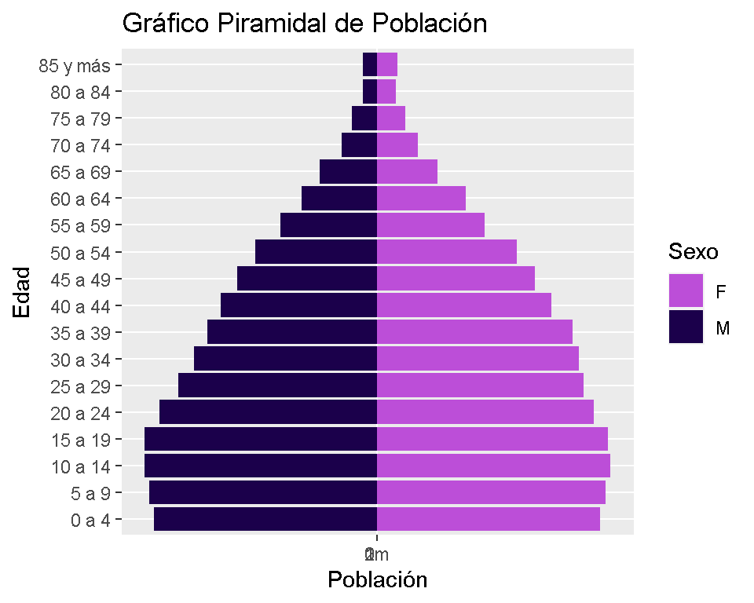

En el siguiente mapa se observa como se distribuye la población sobre la región:

[interactive chart not shown]

### Grupos de población

- Población total respecto al país: 0%. Este valor indica el peso poblacional de la zona metropolitana en relación con la población total de México.
- Población Masculina: 48%
- Población Femenina: 52%
- Relación M-F: 94.437. Este valor indica la proporción de hombres por cada mujer en la zona metropolitana.

### Vivienda

El CPV 2020 también proporciona información sobre la vivienda en la zona metropolitana, a continuación se presentan los principales resultados:

### Socioeconómicos

La población en terminos de la poblacioón economicamente activa esta descrita por:

- Porcentaje de población de 12 años y más económicamente activa: 52%
- Porcentaje de población de 12 años y más no económicamente activa: 26% `

### Educación

La educación de la zona metropolitana esta caracterizada por los siguientes estadísticos:

- Porcentaje de población de 15 años y más sin escolaridad:2%
- Porcentaje de población de 15 años y más con al menos un grado aprobado en primaria: 74%
- Porcentaje de población de 15 años y más con educación básica completa: 22%
- Porcentaje de población de 15 años y más con secundaria o equivalente incompleta:3%
- Porcentaje de población de 18 años y más con al menos un grado aprobado en educación media superior: 28%

### Salud

La situación de la afiliación a algún servico de salud es la siguiente:

- Porcentaje de población afiliada a servicios de salud: 66%
- Población sin afiliación a servicios de salud:62158

### Indicadores de desarrollo

Finalmente se presentan tres indicadores de desarrollo; los índices son: índice de Desarrollo Humano (IDH), Índice de Marginación (IM) e Índice de Rezago Social (IRS).

IDH es un indicador elaborado por el Programa de Naciones Unidas para el Desarrollo (PNUD), este busca medir la calidad de vida, así como el progreso socioeconómico de cada entidad y municipio; El cálculo del Índice de Desarrollo Humano se realiza a partir de las tres variables: esperanza de vida, educación e ingreso per cápita.

- Muy Alto - IDH mayor de 1.
- Alto - IDH entre 0.80 a 1.
- Medio - IDH entre 0.50 y 0.80.
- Bajo - IDH entre 0 y 0.50
- Muy Bajo - IDH menores a 0.
- El promedio del IDH en 2020 para la zona metropolitana es de 0.726 según datos del PNUD.

El IM es un índice construido por el consejo Nacional de Población (CONAPO). Este índice considera 4 dimensiones estructurales para su construcción: vivienda, ingreso, educación y distribución de la población. El indice se puede ubicar en 5 estratos designados por la ténica de estratificación de Dalenius-Hodges..

Por último, el IRS es construido por el Consejo Nacional de Evaluación de la Política de Desarrollo Social, CONEVAL, este índice incorpora indicadores de educación, de acceso a servicios de salud, de servicios básicos y tiene como finalidad ordenar los municipios según sus carencias sociales. Este índice, al igual que el IM, se clasifica en cinco estratos.

## Datos económicos.

Con base en la información de los subsectores de los 21 sectores principales de la clasificación del SCIAN, extraída de los Censos Económicos del INEGI durante el periodo de 1998-2018, se ha llevado a cabo la agrupación de los datos de cada municipio que pertenece a una zona metropolitana en cinco grandes sectores: Primarios, Construcción, Manufactura, Comercio y Servicios. Esta clasificación se basa en la metodología proporcionada por el INEGI. Se utilizaron las siguientes variables:

- Unidades económicas (UE) [número de unidades]
- Activiso fijos totales (AF) [miles de pesos a precios corrientes]
- Formación bruta de capital fijo (FB) [miles de pesos a precios corrientes]
- Producción bruta total (PB) [miles de pesos a precios corrientes]
- Personal ocupado total (PO) [número de personas]
- Total de remuneraciones (RE) [miles de pesos a precios corrientes]
- Valor agregado censal bruto (VA) [miles de pesos a precios corrientes]

Posteriormente, se replica la metodología utilizada por García y Carranco (2008) para estimar los coeficientes de participación relativa (PR), de localización de la actividad económica (QL), Hirschman-Herfindahl (HH) e Inverso de Hirschman-Herfindahl (IHH).

$PR_ij$=$X_ij/X_in$

$QL_ij$=$(X_ij⁄X_j )/(X_in⁄X_n)$

$HH_ij$=$X_ij/X_in - X_j/X_n$

$IHH_ij$=$1/(X_ij/X_in - X_j/X_n)$

### Cifras brutas

#### 1999

##### UE

| Clave | Municipio | Primarios | Construcción | Manufactura | Comercio | Servicios |
| --- | --- | --- | --- | --- | --- | --- |
| 15006 | Almoloya del Río | 0 | 0 | 239 | 124 | 47 |
| 15012 | Atizapán | 0 | 0 | 121 | 108 | 43 |
| 15019 | Capulhuac | 0 | 0 | 152 | 434 | 166 |
| 15043 | Xalatlaco | 0 | 0 | 67 | 243 | 45 |
| 15098 | Texcalyacac | 0 | 0 | 26 | 62 | 15 |
| 15101 | Tianguistenco | 0 | 0 | 369 | 912 | 327 |

##### AF

| Clave | Municipio | Primarios | Construcción | Manufactura | Comercio | Servicios |
| --- | --- | --- | --- | --- | --- | --- |
| 15006 | Almoloya del Río | 0 | 0 | 5,167 | 3,437 | 4,594 |
| 15012 | Atizapán | 0 | 0 | 7,742 | 5,130 | 5,040 |
| 15019 | Capulhuac | 2,550 | 5 | 158,847 | 26,831 | 2,841,518 |
| 15043 | Xalatlaco | 200 | 928 | 5,927 | 7,219 | 8,212 |
| 15098 | Texcalyacac | 3,020 | 0 | 600 | 1,598 | 2,084 |
| 15101 | Tianguistenco | 200 | 0 | 996,059 | 46,042 | 44,959 |

##### FB

| Clave | Municipio | Primarios | Construcción | Manufactura | Comercio | Servicios |
| --- | --- | --- | --- | --- | --- | --- |
| 15006 | Almoloya del Río | 0 | 0 | 0 | 19 | 15 |
| 15012 | Atizapán | 0 | 0 | 111 | 264 | 0 |
| 15019 | Capulhuac | 0 | 0 | 11,647 | 4,371 | -2,556 |
| 15043 | Xalatlaco | 0 | 0 | 58 | 33 | 39 |
| 15098 | Texcalyacac | 0 | 0 | 0 | 0 | 2 |
| 15101 | Tianguistenco | 0 | 0 | 198,447 | 4,793 | 646 |

##### PB

| Clave | Municipio | Primarios | Construcción | Manufactura | Comercio | Servicios |
| --- | --- | --- | --- | --- | --- | --- |
| 15006 | Almoloya del Río | 0 | 0 | 11,576 | 4,346 | 2,703 |
| 15012 | Atizapán | 0 | 0 | 21,944 | 15,561 | 6,493 |
| 15019 | Capulhuac | 430 | 16 | 1,275,751 | 40,157 | 967,361 |
| 15043 | Xalatlaco | 60 | 1,554 | 17,710 | 8,034 | 6,700 |
| 15098 | Texcalyacac | 360 | 0 | 2,023 | 1,683 | 2,684 |
| 15101 | Tianguistenco | 160 | 0 | 5,411,965 | 157,230 | 59,498 |

##### PO

| Clave | Municipio | Primarios | Construcción | Manufactura | Comercio | Servicios |
| --- | --- | --- | --- | --- | --- | --- |
| 15006 | Almoloya del Río | 0 | 0 | 459 | 181 | 123 |
| 15012 | Atizapán | 0 | 0 | 468 | 323 | 129 |
| 15019 | Capulhuac | 7 | 1 | 1,668 | 666 | 2,052 |
| 15043 | Xalatlaco | 2 | 1 | 359 | 334 | 217 |
| 15098 | Texcalyacac | 80 | 0 | 52 | 97 | 90 |
| 15101 | Tianguistenco | 1 | 0 | 8,232 | 1,728 | 1,433 |

##### RE

| Clave | Municipio | Primarios | Construcción | Manufactura | Comercio | Servicios |
| --- | --- | --- | --- | --- | --- | --- |
| 15006 | Almoloya del Río | 0 | 0 | 456 | 297 | 264 |
| 15012 | Atizapán | 0 | 0 | 2,261 | 2,563 | 577 |
| 15019 | Capulhuac | 15 | 0 | 51,769 | 1,037 | 14,796 |
| 15043 | Xalatlaco | 24 | 150 | 4,207 | 166 | 769 |
| 15098 | Texcalyacac | 0 | 0 | 49 | 23 | 409 |
| 15101 | Tianguistenco | 3 | 0 | 558,510 | 17,406 | 10,709 |

##### VA

| Clave | Municipio | Primarios | Construcción | Manufactura | Comercio | Servicios |
| --- | --- | --- | --- | --- | --- | --- |
| 15006 | Almoloya del Río | 0 | 0 | 6,600 | 3,483 | 1,225 |
| 15012 | Atizapán | 0 | 0 | 12,728 | 11,488 | 2,876 |
| 15019 | Capulhuac | 265 | 15 | 213,147 | 36,167 | 897,504 |
| 15043 | Xalatlaco | 49 | 642 | 8,157 | 6,878 | 2,356 |
| 15098 | Texcalyacac | 336 | 0 | 818 | 1,430 | 939 |
| 15101 | Tianguistenco | 120 | 0 | 1,855,551 | 132,749 | 30,791 |

#### 2004

##### UE

| Clave | Municipio | Primarios | Construcción | Manufactura | Comercio | Servicios |
| --- | --- | --- | --- | --- | --- | --- |
| 15006 | Almoloya del Río | 0 | 0 | 242 | 129 | 41 |
| 15012 | Atizapán | 0 | 0 | 89 | 96 | 52 |
| 15019 | Capulhuac | 0 | 0 | 96 | 535 | 184 |
| 15043 | Xalatlaco | 0 | 0 | 66 | 275 | 73 |
| 15098 | Texcalyacac | 0 | 0 | 14 | 78 | 14 |
| 15101 | Tianguistenco | 0 | 0 | 264 | 1,125 | 458 |

##### AF

| Clave | Municipio | Primarios | Construcción | Manufactura | Comercio | Servicios |
| --- | --- | --- | --- | --- | --- | --- |
| 15006 | Almoloya del Río | 0 | 0 | 9,001 | 6,288 | 5,937 |
| 15012 | Atizapán | 0 | 0 | 20,525 | 15,620 | 4,946 |
| 15019 | Capulhuac | 20 | 0 | 160,356 | 31,192 | 32,910 |
| 15043 | Xalatlaco | 5,000 | 0 | 12,276 | 30,295 | 31,984 |
| 15098 | Texcalyacac | 30 | 0 | 3,698 | 11,384 | 5,930 |
| 15101 | Tianguistenco | 370 | 0 | 1,770,778 | 94,363 | 91,870 |

##### FB

| Clave | Municipio | Primarios | Construcción | Manufactura | Comercio | Servicios |
| --- | --- | --- | --- | --- | --- | --- |
| 15006 | Almoloya del Río | 0 | 0 | 50 | 1 | 0 |
| 15012 | Atizapán | 0 | 0 | 13,125 | 5 | 377 |
| 15019 | Capulhuac | 0 | 0 | -4,912 | 434 | 617 |
| 15043 | Xalatlaco | 0 | 0 | 60 | 325 | 127 |
| 15098 | Texcalyacac | 0 | 0 | 9 | 11 | 3 |
| 15101 | Tianguistenco | 0 | 0 | 82,552 | 5,205 | 2,592 |

##### PB

| Clave | Municipio | Primarios | Construcción | Manufactura | Comercio | Servicios |
| --- | --- | --- | --- | --- | --- | --- |
| 15006 | Almoloya del Río | 0 | 0 | 23,275 | 8,282 | 4,191 |
| 15012 | Atizapán | 0 | 0 | 38,076 | 42,321 | 12,418 |
| 15019 | Capulhuac | 600 | 0 | 1,857,723 | 38,696 | 102,845 |
| 15043 | Xalatlaco | 1,500 | 0 | 14,161 | 23,482 | 13,158 |
| 15098 | Texcalyacac | 250 | 0 | 3,755 | 6,474 | 5,025 |
| 15101 | Tianguistenco | 242 | 0 | 4,274,913 | 228,533 | 146,670 |

##### PO

| Clave | Municipio | Primarios | Construcción | Manufactura | Comercio | Servicios |
| --- | --- | --- | --- | --- | --- | --- |
| 15006 | Almoloya del Río | 0 | 0 | 619 | 265 | 98 |
| 15012 | Atizapán | 0 | 0 | 429 | 414 | 127 |
| 15019 | Capulhuac | 8 | 0 | 1,225 | 1,026 | 1,445 |
| 15043 | Xalatlaco | 14 | 0 | 165 | 581 | 237 |
| 15098 | Texcalyacac | 8 | 0 | 69 | 146 | 149 |
| 15101 | Tianguistenco | 62 | 0 | 7,428 | 2,415 | 1,762 |

##### RE

| Clave | Municipio | Primarios | Construcción | Manufactura | Comercio | Servicios |
| --- | --- | --- | --- | --- | --- | --- |
| 15006 | Almoloya del Río | 0 | 0 | 1,382 | 449 | 511 |
| 15012 | Atizapán | 0 | 0 | 5,035 | 15,243 | 770 |
| 15019 | Capulhuac | 67 | 0 | 34,430 | 3,340 | 11,133 |
| 15043 | Xalatlaco | 292 | 0 | 1,611 | 1,071 | 827 |
| 15098 | Texcalyacac | 0 | 0 | 306 | 282 | 133 |
| 15101 | Tianguistenco | 12 | 0 | 672,246 | 27,075 | 35,733 |

##### VA

| Clave | Municipio | Primarios | Construcción | Manufactura | Comercio | Servicios |
| --- | --- | --- | --- | --- | --- | --- |
| 15006 | Almoloya del Río | 0 | 0 | 13,938 | 6,700 | 2,246 |
| 15012 | Atizapán | 0 | 0 | 30,152 | 37,797 | 4,314 |
| 15019 | Capulhuac | 332 | 0 | 233,873 | 34,230 | 49,753 |
| 15043 | Xalatlaco | 1,165 | 0 | 9,041 | 20,939 | 6,768 |
| 15098 | Texcalyacac | 236 | 0 | 1,809 | 5,953 | 3,226 |
| 15101 | Tianguistenco | 229 | 0 | 1,098,572 | 182,577 | 72,699 |

#### 2009

##### UE

| Clave | Municipio | Primarios | Construcción | Manufactura | Comercio | Servicios |
| --- | --- | --- | --- | --- | --- | --- |
| 15006 | Almoloya del Río | 0 | 0 | 443 | 186 | 87 |
| 15012 | Atizapán | 0 | 0 | 204 | 173 | 58 |
| 15019 | Capulhuac | 0 | 0 | 181 | 632 | 261 |
| 15043 | Xalatlaco | 0 | 0 | 147 | 428 | 101 |
| 15098 | Texcalyacac | 0 | 0 | 26 | 92 | 21 |
| 15101 | Tianguistenco | 0 | 0 | 453 | 1,563 | 834 |

##### AF

| Clave | Municipio | Primarios | Construcción | Manufactura | Comercio | Servicios |
| --- | --- | --- | --- | --- | --- | --- |
| 15006 | Almoloya del Río | 0 | 0 | 4,227 | 9,495 | 9,330 |
| 15012 | Atizapán | 0 | 2,570 | 77,716 | 12,210 | 18,554 |
| 15019 | Capulhuac | 0 | 0 | 506,257 | 33,468 | 68,621 |
| 15043 | Xalatlaco | 1,003 | 0 | 10,030 | 50,645 | 21,697 |
| 15098 | Texcalyacac | 180 | 0 | 3,162 | 15,108 | 6,897 |
| 15101 | Tianguistenco | 144 | 121 | 2,366,158 | 300,363 | 189,994 |

##### FB

| Clave | Municipio | Primarios | Construcción | Manufactura | Comercio | Servicios |
| --- | --- | --- | --- | --- | --- | --- |
| 15006 | Almoloya del Río | 0 | 0 | 155 | 60 | 43 |
| 15012 | Atizapán | 0 | 0 | 22,073 | 1 | 92 |
| 15019 | Capulhuac | 0 | 0 | 23,929 | 2,267 | 1,226 |
| 15043 | Xalatlaco | 0 | 0 | 25 | 123 | 173 |
| 15098 | Texcalyacac | 80 | 0 | 27 | 78 | 114 |
| 15101 | Tianguistenco | 0 | 0 | 73,362 | 12,213 | 2,884 |

##### PB

| Clave | Municipio | Primarios | Construcción | Manufactura | Comercio | Servicios |
| --- | --- | --- | --- | --- | --- | --- |
| 15006 | Almoloya del Río | 0 | 0 | 49,353 | 11,734 | 9,164 |
| 15012 | Atizapán | 0 | 932 | 52,625 | 12,169 | 16,558 |
| 15019 | Capulhuac | 0 | 14 | 4,597,159 | 88,241 | 250,848 |
| 15043 | Xalatlaco | 144 | 0 | 23,028 | 33,885 | 42,543 |
| 15098 | Texcalyacac | 185 | 0 | 25,882 | 5,809 | 16,627 |
| 15101 | Tianguistenco | 358 | 2,513 | 13,010,426 | 844,129 | 302,454 |

##### PO

| Clave | Municipio | Primarios | Construcción | Manufactura | Comercio | Servicios |
| --- | --- | --- | --- | --- | --- | --- |
| 15006 | Almoloya del Río | 0 | 0 | 1,047 | 426 | 202 |
| 15012 | Atizapán | 0 | 19 | 846 | 404 | 363 |
| 15019 | Capulhuac | 0 | 1 | 2,472 | 1,496 | 3,324 |
| 15043 | Xalatlaco | 6 | 0 | 335 | 876 | 668 |
| 15098 | Texcalyacac | 3 | 0 | 131 | 237 | 204 |
| 15101 | Tianguistenco | 104 | 18 | 8,417 | 3,910 | 2,779 |

##### RE

| Clave | Municipio | Primarios | Construcción | Manufactura | Comercio | Servicios |
| --- | --- | --- | --- | --- | --- | --- |
| 15006 | Almoloya del Río | 0 | 0 | 4,277 | 1,480 | 946 |
| 15012 | Atizapán | 0 | 436 | 7,825 | 2,075 | 5,632 |
| 15019 | Capulhuac | 0 | 0 | 111,555 | 3,962 | 16,595 |
| 15043 | Xalatlaco | 0 | 0 | 1,676 | 3,393 | 4,667 |
| 15098 | Texcalyacac | 110 | 0 | 3,468 | 1,498 | 1,139 |
| 15101 | Tianguistenco | 18 | 777 | 1,254,541 | 53,368 | 70,484 |

##### VA

| Clave | Municipio | Primarios | Construcción | Manufactura | Comercio | Servicios |
| --- | --- | --- | --- | --- | --- | --- |
| 15006 | Almoloya del Río | 0 | 0 | 31,904 | 9,207 | 4,892 |
| 15012 | Atizapán | 0 | 436 | 26,651 | 9,684 | 7,966 |
| 15019 | Capulhuac | 0 | 9 | 738,256 | 50,632 | 96,210 |
| 15043 | Xalatlaco | 141 | 0 | 8,560 | 28,366 | 17,267 |
| 15098 | Texcalyacac | 158 | 0 | 11,796 | 4,492 | 11,995 |
| 15101 | Tianguistenco | 321 | 777 | 3,592,868 | 661,982 | 166,607 |

#### 2014

##### UE

| Clave | Municipio | Primarios | Construcción | Manufactura | Comercio | Servicios |
| --- | --- | --- | --- | --- | --- | --- |
| 15006 | Almoloya del Río | 0 | 0 | 468 | 231 | 122 |
| 15012 | Atizapán | 0 | 0 | 184 | 236 | 88 |
| 15019 | Capulhuac | 0 | 0 | 182 | 769 | 1,051 |
| 15043 | Xalatlaco | 0 | 0 | 157 | 482 | 254 |
| 15098 | Texcalyacac | 0 | 0 | 44 | 108 | 36 |
| 15101 | Tianguistenco | 0 | 0 | 576 | 1,605 | 1,098 |

##### AF

| Clave | Municipio | Primarios | Construcción | Manufactura | Comercio | Servicios |
| --- | --- | --- | --- | --- | --- | --- |
| 15006 | Almoloya del Río | 0 | 0 | 7,330 | 5,549 | 2,725 |
| 15012 | Atizapán | 0 | 0 | 13,776 | 63,022 | 5,206 |
| 15019 | Capulhuac | 0 | 0 | 361,486 | 103,947 | 109,203 |
| 15043 | Xalatlaco | 0 | 0 | 19,048 | 64,350 | 31,854 |
| 15098 | Texcalyacac | 0 | 0 | 1,144 | 5,841 | 2,337 |
| 15101 | Tianguistenco | 0 | 0 | 836,487 | 328,209 | 171,955 |

##### FB

| Clave | Municipio | Primarios | Construcción | Manufactura | Comercio | Servicios |
| --- | --- | --- | --- | --- | --- | --- |
| 15006 | Almoloya del Río | 0 | 0 | -81 | 563 | 53 |
| 15012 | Atizapán | 0 | 0 | 958 | 47,822 | 1,773 |
| 15019 | Capulhuac | 0 | 0 | 21,802 | 3,450 | 2,618 |
| 15043 | Xalatlaco | 0 | 0 | 172 | 522 | 214 |
| 15098 | Texcalyacac | 0 | 0 | 2 | 183 | 128 |
| 15101 | Tianguistenco | 0 | 0 | 41,777 | 9,620 | 23,968 |

##### PB

| Clave | Municipio | Primarios | Construcción | Manufactura | Comercio | Servicios |
| --- | --- | --- | --- | --- | --- | --- |
| 15006 | Almoloya del Río | 0 | 0 | 44,922 | 15,256 | 14,781 |
| 15012 | Atizapán | 0 | 0 | 46,887 | 49,403 | 14,804 |
| 15019 | Capulhuac | 0 | 0 | 266,289 | 327,204 | 260,196 |
| 15043 | Xalatlaco | 0 | 0 | 54,345 | 62,650 | 51,771 |
| 15098 | Texcalyacac | 0 | 0 | 5,317 | 13,012 | 2,920 |
| 15101 | Tianguistenco | 0 | 0 | 3,234,540 | 544,037 | 297,637 |

##### PO

| Clave | Municipio | Primarios | Construcción | Manufactura | Comercio | Servicios |
| --- | --- | --- | --- | --- | --- | --- |
| 15006 | Almoloya del Río | 0 | 0 | 932 | 378 | 209 |
| 15012 | Atizapán | 0 | 0 | 778 | 623 | 154 |
| 15019 | Capulhuac | 0 | 0 | 645 | 1,398 | 2,669 |
| 15043 | Xalatlaco | 0 | 0 | 300 | 807 | 480 |
| 15098 | Texcalyacac | 0 | 0 | 80 | 173 | 60 |
| 15101 | Tianguistenco | 0 | 0 | 5,133 | 3,551 | 2,770 |

##### RE

| Clave | Municipio | Primarios | Construcción | Manufactura | Comercio | Servicios |
| --- | --- | --- | --- | --- | --- | --- |
| 15006 | Almoloya del Río | 0 | 0 | 3,477 | 1,168 | 598 |
| 15012 | Atizapán | 0 | 0 | 10,316 | 10,562 | 620 |
| 15019 | Capulhuac | 0 | 0 | 27,636 | 4,871 | 5,534 |
| 15043 | Xalatlaco | 0 | 0 | 1,588 | 1,674 | 1,325 |
| 15098 | Texcalyacac | 0 | 0 | 667 | 965 | 237 |
| 15101 | Tianguistenco | 0 | 0 | 444,032 | 56,906 | 55,215 |

##### VA

| Clave | Municipio | Primarios | Construcción | Manufactura | Comercio | Servicios |
| --- | --- | --- | --- | --- | --- | --- |
| 15006 | Almoloya del Río | 0 | 0 | 27,374 | 13,092 | 7,137 |
| 15012 | Atizapán | 0 | 0 | 30,467 | 30,214 | 8,397 |
| 15019 | Capulhuac | 0 | 0 | 52,628 | 190,760 | 91,267 |
| 15043 | Xalatlaco | 0 | 0 | 26,703 | 51,942 | 26,515 |
| 15098 | Texcalyacac | 0 | 0 | 3,289 | 11,224 | 1,300 |
| 15101 | Tianguistenco | 0 | 0 | 874,047 | 393,443 | 169,075 |

#### 2019

##### UE

| Clave | Municipio | Primarios | Construcción | Manufactura | Comercio | Servicios |
| --- | --- | --- | --- | --- | --- | --- |
| 15006 | Almoloya del Río | 0 | 1 | 575 | 262 | 142 |
| 15012 | Atizapán | 1 | 1 | 234 | 282 | 185 |
| 15019 | Capulhuac | 1 | 1 | 212 | 900 | 1,288 |
| 15043 | Xalatlaco | 1 | 0 | 179 | 563 | 330 |
| 15098 | Texcalyacac | 0 | 1 | 59 | 142 | 102 |
| 15101 | Tianguistenco | 4 | 3 | 671 | 1,945 | 1,345 |

##### AF

| Clave | Municipio | Primarios | Construcción | Manufactura | Comercio | Servicios |
| --- | --- | --- | --- | --- | --- | --- |
| 15006 | Almoloya del Río | 0 | 0 | 5,167 | 16,539 | 13,239 |
| 15012 | Atizapán | 0 | 0 | 24,597 | 86,921 | 20,397 |
| 15019 | Capulhuac | 0 | 0 | 74,052 | 99,491 | 137,544 |
| 15043 | Xalatlaco | 0 | 0 | 12,651 | 45,242 | 24,909 |
| 15098 | Texcalyacac | 0 | 0 | 2,961 | 7,223 | 2,612 |
| 15101 | Tianguistenco | 0 | 102 | 916,196 | 779,551 | 390,690 |

##### FB

| Clave | Municipio | Primarios | Construcción | Manufactura | Comercio | Servicios |
| --- | --- | --- | --- | --- | --- | --- |
| 15006 | Almoloya del Río | 0 | 0 | 45 | 90 | -358 |
| 15012 | Atizapán | 0 | 0 | 16 | -26,275 | 30 |
| 15019 | Capulhuac | 0 | 0 | 234 | 8,802 | 3,278 |
| 15043 | Xalatlaco | 0 | 0 | 26 | 316 | 140 |
| 15098 | Texcalyacac | 0 | 0 | 1 | 4 | 0 |
| 15101 | Tianguistenco | 0 | 0 | 68,950 | 30,772 | 5,308 |

##### PB

| Clave | Municipio | Primarios | Construcción | Manufactura | Comercio | Servicios |
| --- | --- | --- | --- | --- | --- | --- |
| 15006 | Almoloya del Río | 0 | 0 | 23,661 | 28,053 | 8,584 |
| 15012 | Atizapán | 0 | 0 | 95,164 | 119,486 | 13,353 |
| 15019 | Capulhuac | 0 | 0 | 1,120,904 | 337,455 | 415,219 |
| 15043 | Xalatlaco | 0 | 0 | 55,407 | 75,254 | 56,344 |
| 15098 | Texcalyacac | 0 | 0 | 11,157 | 8,171 | 7,828 |
| 15101 | Tianguistenco | 0 | 590 | 7,129,106 | 1,084,992 | 483,925 |

##### PO

| Clave | Municipio | Primarios | Construcción | Manufactura | Comercio | Servicios |
| --- | --- | --- | --- | --- | --- | --- |
| 15006 | Almoloya del Río | 0 | 0 | 179 | 414 | 140 |
| 15012 | Atizapán | 0 | 0 | 813 | 582 | 156 |
| 15019 | Capulhuac | 0 | 0 | 649 | 1,534 | 3,440 |
| 15043 | Xalatlaco | 0 | 0 | 352 | 880 | 526 |
| 15098 | Texcalyacac | 0 | 0 | 94 | 153 | 125 |
| 15101 | Tianguistenco | 0 | 5 | 6,422 | 4,603 | 3,456 |

##### RE

| Clave | Municipio | Primarios | Construcción | Manufactura | Comercio | Servicios |
| --- | --- | --- | --- | --- | --- | --- |
| 15006 | Almoloya del Río | 0 | 0 | 1,989 | 2,831 | 846 |
| 15012 | Atizapán | 0 | 0 | 19,681 | 20,907 | 2,004 |
| 15019 | Capulhuac | 0 | 0 | 45,748 | 20,318 | 28,615 |
| 15043 | Xalatlaco | 0 | 0 | 3,907 | 5,309 | 4,710 |
| 15098 | Texcalyacac | 0 | 0 | 1,237 | 711 | 2,175 |
| 15101 | Tianguistenco | 0 | 0 | 631,970 | 97,664 | 82,036 |

##### VA

| Clave | Municipio | Primarios | Construcción | Manufactura | Comercio | Servicios |
| --- | --- | --- | --- | --- | --- | --- |
| 15006 | Almoloya del Río | 0 | 0 | 9,194 | 23,149 | 4,444 |
| 15012 | Atizapán | 0 | 0 | 55,314 | 96,527 | 7,097 |
| 15019 | Capulhuac | 0 | 0 | 451,603 | 292,684 | 158,791 |
| 15043 | Xalatlaco | 0 | 0 | 23,128 | 61,976 | 25,068 |
| 15098 | Texcalyacac | 0 | 0 | 5,125 | 6,359 | 4,825 |
| 15101 | Tianguistenco | 0 | 39 | 1,835,289 | 824,644 | 240,962 |

### Coeficientes de localización (QL)

#### 1999

##### UE

| Clave | Municipio | Primarios | Construcción | Manufactura | Comercio | Servicios |
| --- | --- | --- | --- | --- | --- | --- |
| 15006 | Almoloya del Río | 0.0000 | 0.0000 | 5.2537 | 0.5732 | 0.3249 |
| 15012 | Atizapán | 0.0000 | 0.0000 | 4.0093 | 0.7525 | 0.4481 |
| 15019 | Capulhuac | 0.0000 | 0.0000 | 1.8217 | 1.0938 | 0.6257 |
| 15043 | Xalatlaco | 0.0000 | 0.0000 | 1.7010 | 1.2973 | 0.3593 |
| 15098 | Texcalyacac | 0.0000 | 0.0000 | 2.2750 | 1.1409 | 0.4128 |
| 15101 | Tianguistenco | 0.0000 | 0.0000 | 2.0682 | 1.0749 | 0.5764 |

##### AF

| Clave | Municipio | Primarios | Construcción | Manufactura | Comercio | Servicios |
| --- | --- | --- | --- | --- | --- | --- |
| 15006 | Almoloya del Río | 0.0000 | 0.0000 | 1.1506 | 3.4288 | 0.6396 |
| 15012 | Atizapán | 0.0000 | 0.0000 | 1.2703 | 3.7709 | 0.5170 |
| 15019 | Capulhuac | 0.0346 | 0.0001 | 0.1541 | 0.1166 | 1.7233 |
| 15043 | Xalatlaco | 0.3655 | 2.7106 | 0.7747 | 4.2271 | 0.6710 |
| 15098 | Texcalyacac | 16.9935 | 0.0000 | 0.2415 | 2.8814 | 0.5244 |
| 15101 | Tianguistenco | 0.0076 | 0.0000 | 2.6925 | 0.5576 | 0.0760 |

##### FB

[output not shown]

##### PB

| Clave | Municipio | Primarios | Construcción | Manufactura | Comercio | Servicios |
| --- | --- | --- | --- | --- | --- | --- |
| 15006 | Almoloya del Río | 0.0000 | 0.0000 | 1.2561 | 1.6699 | 0.4544 |
| 15012 | Atizapán | 0.0000 | 0.0000 | 1.0079 | 2.5311 | 0.4621 |
| 15019 | Capulhuac | 0.0189 | 0.0002 | 1.1290 | 0.1258 | 1.3263 |
| 15043 | Xalatlaco | 0.1765 | 1.2645 | 1.0509 | 1.6881 | 0.6159 |
| 15098 | Texcalyacac | 5.3445 | 0.0000 | 0.6057 | 1.7843 | 1.2450 |
| 15101 | Tianguistenco | 0.0028 | 0.0000 | 1.9431 | 0.1999 | 0.0331 |

##### PO

| Clave | Municipio | Primarios | Construcción | Manufactura | Comercio | Servicios |
| --- | --- | --- | --- | --- | --- | --- |
| 15006 | Almoloya del Río | 0.0000 | 0.0000 | 1.9488 | 0.9143 | 0.4365 |
| 15012 | Atizapán | 0.0000 | 0.0000 | 1.6479 | 1.3531 | 0.3797 |
| 15019 | Capulhuac | 0.1796 | 0.0042 | 1.2297 | 0.5842 | 1.2646 |
| 15043 | Xalatlaco | 0.2470 | 0.0204 | 1.2738 | 1.4099 | 0.6436 |
| 15098 | Texcalyacac | 28.2722 | 0.0000 | 0.5281 | 1.1719 | 0.7640 |
| 15101 | Tianguistenco | 0.0099 | 0.0000 | 2.3405 | 0.5845 | 0.3406 |

##### RE

| Clave | Municipio | Primarios | Construcción | Manufactura | Comercio | Servicios |
| --- | --- | --- | --- | --- | --- | --- |
| 15006 | Almoloya del Río | 0.0000 | 0.0000 | 1.2127 | 2.0566 | 0.5753 |
| 15012 | Atizapán | 0.0000 | 0.0000 | 1.1322 | 3.3418 | 0.2368 |
| 15019 | Capulhuac | 0.0196 | 0.0000 | 2.0707 | 0.1080 | 0.4850 |
| 15043 | Xalatlaco | 0.3981 | 1.0980 | 2.1404 | 0.2199 | 0.3206 |
| 15098 | Texcalyacac | 0.0000 | 0.0000 | 0.2755 | 0.3367 | 1.8845 |
| 15101 | Tianguistenco | 0.0005 | 0.0000 | 2.5750 | 0.2089 | 0.0405 |

##### VA

| Clave | Municipio | Primarios | Construcción | Manufactura | Comercio | Servicios |
| --- | --- | --- | --- | --- | --- | --- |
| 15006 | Almoloya del Río | 0.0000 | 0.0000 | 1.5841 | 1.3828 | 0.2890 |
| 15012 | Atizapán | 0.0000 | 0.0000 | 1.2751 | 1.9037 | 0.2832 |
| 15019 | Capulhuac | 0.0196 | 0.0006 | 0.5043 | 0.1416 | 2.0875 |
| 15043 | Xalatlaco | 0.2305 | 1.5970 | 1.2243 | 1.7077 | 0.3476 |
| 15098 | Texcalyacac | 8.1117 | 0.0000 | 0.6302 | 1.8223 | 0.7111 |
| 15101 | Tianguistenco | 0.0051 | 0.0000 | 2.4941 | 0.2952 | 0.0407 |

#### 2004

##### UE

| Clave | Municipio | Primarios | Construcción | Manufactura | Comercio | Servicios |
| --- | --- | --- | --- | --- | --- | --- |
| 15006 | Almoloya del Río | 0.0000 | 0.0000 | 6.0093 | 0.5799 | 0.2799 |
| 15012 | Atizapán | 0.0000 | 0.0000 | 3.8419 | 0.7502 | 0.6171 |
| 15019 | Capulhuac | 0.0000 | 0.0000 | 1.2051 | 1.2158 | 0.6349 |
| 15043 | Xalatlaco | 0.0000 | 0.0000 | 1.6310 | 1.2302 | 0.4959 |
| 15098 | Texcalyacac | 0.0000 | 0.0000 | 1.3512 | 1.3628 | 0.3714 |
| 15101 | Tianguistenco | 0.0000 | 0.0000 | 1.4623 | 1.1281 | 0.6974 |

##### AF

| Clave | Municipio | Primarios | Construcción | Manufactura | Comercio | Servicios |
| --- | --- | --- | --- | --- | --- | --- |
| 15006 | Almoloya del Río | 0.0000 | 0.0000 | 1.1575 | 3.2939 | 0.5420 |
| 15012 | Atizapán | 0.0000 | 0.0000 | 1.3634 | 4.2267 | 0.2332 |
| 15019 | Capulhuac | 0.0054 | 0.0000 | 1.9499 | 1.5450 | 0.2841 |
| 15043 | Xalatlaco | 3.7791 | 0.0000 | 0.4212 | 4.2342 | 0.7790 |
| 15098 | Texcalyacac | 0.0857 | 0.0000 | 0.4797 | 6.0155 | 0.5461 |
| 15101 | Tianguistenco | 0.0114 | 0.0000 | 2.4694 | 0.5360 | 0.0909 |

##### FB

[output not shown]

##### PB

| Clave | Municipio | Primarios | Construcción | Manufactura | Comercio | Servicios |
| --- | --- | --- | --- | --- | --- | --- |
| 15006 | Almoloya del Río | 0.0000 | 0.0000 | 1.4096 | 1.6867 | 0.3267 |
| 15012 | Atizapán | 0.0000 | 0.0000 | 0.8882 | 3.3196 | 0.3728 |
| 15019 | Capulhuac | 0.0294 | 0.0000 | 2.0111 | 0.1409 | 0.1433 |
| 15043 | Xalatlaco | 2.8066 | 0.0000 | 0.5862 | 3.2687 | 0.7010 |
| 15098 | Texcalyacac | 1.5780 | 0.0000 | 0.5244 | 3.0400 | 0.9031 |
| 15101 | Tianguistenco | 0.0051 | 0.0000 | 1.9902 | 0.3578 | 0.0879 |

##### PO

| Clave | Municipio | Primarios | Construcción | Manufactura | Comercio | Servicios |
| --- | --- | --- | --- | --- | --- | --- |
| 15006 | Almoloya del Río | 0.0000 | 0.0000 | 2.3924 | 0.9230 | 0.2561 |
| 15012 | Atizapán | 0.0000 | 0.0000 | 1.6786 | 1.4599 | 0.3360 |
| 15019 | Capulhuac | 0.2613 | 0.0000 | 1.2552 | 0.9474 | 1.0012 |
| 15043 | Xalatlaco | 1.6988 | 0.0000 | 0.6281 | 1.9932 | 0.6101 |
| 15098 | Texcalyacac | 2.6018 | 0.0000 | 0.7040 | 1.3424 | 1.0280 |
| 15101 | Tianguistenco | 0.6429 | 0.0000 | 2.4164 | 0.7080 | 0.3876 |

##### RE

| Clave | Municipio | Primarios | Construcción | Manufactura | Comercio | Servicios |
| --- | --- | --- | --- | --- | --- | --- |
| 15006 | Almoloya del Río | 0.0000 | 0.0000 | 1.6826 | 1.2263 | 0.4771 |
| 15012 | Atizapán | 0.0000 | 0.0000 | 0.6821 | 4.6323 | 0.0800 |
| 15019 | Capulhuac | 0.1437 | 0.0000 | 2.0047 | 0.4363 | 0.4971 |
| 15043 | Xalatlaco | 8.0696 | 0.0000 | 1.2085 | 1.8023 | 0.4758 |
| 15098 | Texcalyacac | 0.0000 | 0.0000 | 1.2101 | 2.5018 | 0.4034 |
| 15101 | Tianguistenco | 0.0017 | 0.0000 | 2.6077 | 0.2356 | 0.1063 |

##### VA

| Clave | Municipio | Primarios | Construcción | Manufactura | Comercio | Servicios |
| --- | --- | --- | --- | --- | --- | --- |
| 15006 | Almoloya del Río | 0.0000 | 0.0000 | 1.8739 | 1.4862 | 0.2233 |
| 15012 | Atizapán | 0.0000 | 0.0000 | 1.2837 | 2.6550 | 0.1358 |
| 15019 | Capulhuac | 0.0648 | 0.0000 | 2.2614 | 0.5461 | 0.3558 |
| 15043 | Xalatlaco | 1.9072 | 0.0000 | 0.7337 | 2.8035 | 0.4062 |
| 15098 | Texcalyacac | 1.3050 | 0.0000 | 0.4959 | 2.6923 | 0.6540 |
| 15101 | Tianguistenco | 0.0105 | 0.0000 | 2.4961 | 0.6844 | 0.1222 |

#### 2009

##### UE

| Clave | Municipio | Primarios | Construcción | Manufactura | Comercio | Servicios |
| --- | --- | --- | --- | --- | --- | --- |
| 15006 | Almoloya del Río | 0.0000 | 0.0000 | 6.0071 | 0.5109 | 0.3188 |
| 15012 | Atizapán | 0.0000 | 0.0000 | 4.5531 | 0.7822 | 0.3498 |
| 15019 | Capulhuac | 0.0000 | 0.0000 | 1.6362 | 1.1573 | 0.6376 |
| 15043 | Xalatlaco | 0.0000 | 0.0000 | 2.1113 | 1.2452 | 0.3920 |
| 15098 | Texcalyacac | 0.0000 | 0.0000 | 1.8161 | 1.3017 | 0.3964 |
| 15101 | Tianguistenco | 0.0000 | 0.0000 | 1.5432 | 1.0786 | 0.7678 |

##### AF

| Clave | Municipio | Primarios | Construcción | Manufactura | Comercio | Servicios |
| --- | --- | --- | --- | --- | --- | --- |
| 15006 | Almoloya del Río | 0.0000 | 0.0000 | 0.6856 | 4.3802 | 0.6705 |
| 15012 | Atizapán | 0.0000 | 1.4574 | 2.6166 | 1.1692 | 0.2768 |
| 15019 | Capulhuac | 0.0000 | 0.0000 | 3.1114 | 0.5850 | 0.1869 |
| 15043 | Xalatlaco | 0.6347 | 0.0000 | 0.4498 | 6.4596 | 0.4311 |
| 15098 | Texcalyacac | 0.3747 | 0.0000 | 0.4664 | 6.3385 | 0.4507 |
| 15101 | Tianguistenco | 0.0027 | 0.0027 | 3.0968 | 1.1181 | 0.1102 |

##### FB

[output not shown]

##### PB

| Clave | Municipio | Primarios | Construcción | Manufactura | Comercio | Servicios |
| --- | --- | --- | --- | --- | --- | --- |
| 15006 | Almoloya del Río | 0.0000 | 0.0000 | 1.4476 | 1.5965 | 0.3730 |
| 15012 | Atizapán | 0.0000 | 0.2679 | 1.3178 | 1.4136 | 0.5754 |
| 15019 | Capulhuac | 0.0000 | 0.0001 | 1.9190 | 0.1709 | 0.1453 |
| 15043 | Xalatlaco | 0.0798 | 0.0000 | 0.4764 | 3.2518 | 1.2215 |
| 15098 | Texcalyacac | 0.2106 | 0.0000 | 1.0996 | 1.1447 | 0.9803 |
| 15101 | Tianguistenco | 0.0014 | 0.0042 | 1.8933 | 0.5698 | 0.0611 |

##### PO

| Clave | Municipio | Primarios | Construcción | Manufactura | Comercio | Servicios |
| --- | --- | --- | --- | --- | --- | --- |
| 15006 | Almoloya del Río | 0.0000 | 0.0000 | 2.6291 | 0.8945 | 0.2798 |
| 15012 | Atizapán | 0.0000 | 0.2929 | 2.1803 | 0.8707 | 0.5160 |
| 15019 | Capulhuac | 0.0000 | 0.0035 | 1.4257 | 0.7215 | 1.0574 |
| 15043 | Xalatlaco | 0.4459 | 0.0000 | 0.7475 | 1.6345 | 0.8221 |
| 15098 | Texcalyacac | 0.7308 | 0.0000 | 0.9582 | 1.4496 | 0.8231 |
| 15101 | Tianguistenco | 0.9566 | 0.0297 | 2.3248 | 0.9031 | 0.4234 |

##### RE

| Clave | Municipio | Primarios | Construcción | Manufactura | Comercio | Servicios |
| --- | --- | --- | --- | --- | --- | --- |
| 15006 | Almoloya del Río | 0.0000 | 0.0000 | 1.9354 | 1.7321 | 0.2869 |
| 15012 | Atizapán | 0.0000 | 0.7291 | 1.4864 | 1.0194 | 0.7171 |
| 15019 | Capulhuac | 0.0000 | 0.0000 | 2.5612 | 0.2353 | 0.2554 |
| 15043 | Xalatlaco | 0.0000 | 0.0000 | 0.5221 | 2.7339 | 0.9746 |
| 15098 | Texcalyacac | 1.3062 | 0.0000 | 1.6925 | 1.8908 | 0.3726 |
| 15101 | Tianguistenco | 0.0010 | 0.0150 | 2.7590 | 0.3036 | 0.1039 |

##### VA

| Clave | Municipio | Primarios | Construcción | Manufactura | Comercio | Servicios |
| --- | --- | --- | --- | --- | --- | --- |
| 15006 | Almoloya del Río | 0.0000 | 0.0000 | 1.9568 | 1.3876 | 0.2398 |
| 15012 | Atizapán | 0.0000 | 0.3292 | 1.6808 | 1.5008 | 0.4016 |
| 15019 | Capulhuac | 0.0000 | 0.0003 | 2.3534 | 0.3966 | 0.2452 |
| 15043 | Xalatlaco | 0.0915 | 0.0000 | 0.4445 | 3.6195 | 0.7168 |
| 15098 | Texcalyacac | 0.1958 | 0.0000 | 1.1702 | 1.0950 | 0.9512 |
| 15101 | Tianguistenco | 0.0026 | 0.0059 | 2.2922 | 1.0378 | 0.0850 |

#### 2014

##### UE

| Clave | Municipio | Primarios | Construcción | Manufactura | Comercio | Servicios |
| --- | --- | --- | --- | --- | --- | --- |
| 15006 | Almoloya del Río | 0.0000 | 0.0000 | 5.8042 | 0.5764 | 0.3651 |
| 15012 | Atizapán | 0.0000 | 0.0000 | 3.6880 | 0.9517 | 0.4256 |
| 15019 | Capulhuac | 0.0000 | 0.0000 | 0.9257 | 0.7869 | 1.2899 |
| 15043 | Xalatlaco | 0.0000 | 0.0000 | 1.7902 | 1.1058 | 0.6989 |
| 15098 | Texcalyacac | 0.0000 | 0.0000 | 2.3831 | 1.1769 | 0.4705 |
| 15101 | Tianguistenco | 0.0000 | 0.0000 | 1.7886 | 1.0028 | 0.8228 |

##### AF

| Clave | Municipio | Primarios | Construcción | Manufactura | Comercio | Servicios |
| --- | --- | --- | --- | --- | --- | --- |
| 15006 | Almoloya del Río | 0.0000 | 0.0000 | 1.7180 | 3.2351 | 0.2958 |
| 15012 | Atizapán | 0.0000 | 0.0000 | 0.6144 | 6.9914 | 0.1075 |
| 15019 | Capulhuac | 0.0000 | 0.0000 | 2.3007 | 1.6456 | 0.3218 |
| 15043 | Xalatlaco | 0.0000 | 0.0000 | 0.6045 | 5.0793 | 0.4681 |
| 15098 | Texcalyacac | 0.0000 | 0.0000 | 0.4488 | 5.7001 | 0.4246 |
| 15101 | Tianguistenco | 0.0000 | 0.0000 | 2.2888 | 2.2338 | 0.2179 |

##### FB

[output not shown]

##### PB

| Clave | Municipio | Primarios | Construcción | Manufactura | Comercio | Servicios |
| --- | --- | --- | --- | --- | --- | --- |
| 15006 | Almoloya del Río | 0.0000 | 0.0000 | 1.2263 | 1.7069 | 0.5536 |
| 15012 | Atizapán | 0.0000 | 0.0000 | 0.8636 | 3.7295 | 0.3741 |
| 15019 | Capulhuac | 0.0000 | 0.0000 | 0.6383 | 3.2145 | 0.8558 |
| 15043 | Xalatlaco | 0.0000 | 0.0000 | 0.6589 | 3.1133 | 0.8613 |
| 15098 | Texcalyacac | 0.0000 | 0.0000 | 0.5120 | 5.1356 | 0.3858 |
| 15101 | Tianguistenco | 0.0000 | 0.0000 | 1.6238 | 1.1193 | 0.2050 |

##### PO

| Clave | Municipio | Primarios | Construcción | Manufactura | Comercio | Servicios |
| --- | --- | --- | --- | --- | --- | --- |
| 15006 | Almoloya del Río | 0.0000 | 0.0000 | 2.5394 | 0.8726 | 0.3133 |
| 15012 | Atizapán | 0.0000 | 0.0000 | 2.0707 | 1.4048 | 0.2255 |
| 15019 | Capulhuac | 0.0000 | 0.0000 | 0.5665 | 1.0403 | 1.2896 |
| 15043 | Xalatlaco | 0.0000 | 0.0000 | 0.7824 | 1.7830 | 0.6886 |
| 15098 | Texcalyacac | 0.0000 | 0.0000 | 1.0578 | 1.9380 | 0.4364 |
| 15101 | Tianguistenco | 0.0000 | 0.0000 | 1.8547 | 1.0871 | 0.5506 |

##### RE

| Clave | Municipio | Primarios | Construcción | Manufactura | Comercio | Servicios |
| --- | --- | --- | --- | --- | --- | --- |
| 15006 | Almoloya del Río | 0.0000 | 0.0000 | 1.9426 | 1.6208 | 0.2369 |
| 15012 | Atizapán | 0.0000 | 0.0000 | 1.4056 | 3.5745 | 0.0599 |
| 15019 | Capulhuac | 0.0000 | 0.0000 | 2.1280 | 0.9316 | 0.3022 |
| 15043 | Xalatlaco | 0.0000 | 0.0000 | 1.0141 | 2.6552 | 0.6000 |
| 15098 | Texcalyacac | 0.0000 | 0.0000 | 1.0454 | 3.7565 | 0.2634 |
| 15101 | Tianguistenco | 0.0000 | 0.0000 | 2.3387 | 0.7444 | 0.2062 |

##### VA

| Clave | Municipio | Primarios | Construcción | Manufactura | Comercio | Servicios |
| --- | --- | --- | --- | --- | --- | --- |
| 15006 | Almoloya del Río | 0.0000 | 0.0000 | 1.7100 | 1.5586 | 0.3277 |
| 15012 | Atizapán | 0.0000 | 0.0000 | 1.3115 | 2.4787 | 0.2657 |
| 15019 | Capulhuac | 0.0000 | 0.0000 | 0.4676 | 3.2303 | 0.5961 |
| 15043 | Xalatlaco | 0.0000 | 0.0000 | 0.7551 | 2.7991 | 0.5511 |
| 15098 | Texcalyacac | 0.0000 | 0.0000 | 0.6185 | 4.0224 | 0.1797 |
| 15101 | Tianguistenco | 0.0000 | 0.0000 | 1.8092 | 1.5521 | 0.2572 |

#### 2019

##### UE

| Clave | Municipio | Primarios | Construcción | Manufactura | Comercio | Servicios |
| --- | --- | --- | --- | --- | --- | --- |
| 15006 | Almoloya del Río | 0.0000 | 0.1967 | 5.9355 | 0.5700 | 0.3413 |
| 15012 | Atizapán | 0.5987 | 0.2742 | 3.3673 | 0.8553 | 0.6198 |
| 15019 | Capulhuac | 0.1752 | 0.0803 | 0.8929 | 0.7989 | 1.2630 |
| 15043 | Xalatlaco | 0.3923 | 0.0000 | 1.6876 | 1.1187 | 0.7244 |
| 15098 | Texcalyacac | 0.0000 | 0.6341 | 1.9633 | 0.9959 | 0.7903 |
| 15101 | Tianguistenco | 0.4243 | 0.1457 | 1.7107 | 1.0451 | 0.7984 |

##### AF

| Clave | Municipio | Primarios | Construcción | Manufactura | Comercio | Servicios |
| --- | --- | --- | --- | --- | --- | --- |
| 15006 | Almoloya del Río | 0.0000 | 0.0000 | 0.5219 | 2.4177 | 0.7681 |
| 15012 | Atizapán | 0.0000 | 0.0000 | 0.6582 | 3.3660 | 0.3135 |
| 15019 | Capulhuac | 0.0000 | 0.0000 | 0.8403 | 1.6338 | 0.8964 |
| 15043 | Xalatlaco | 0.0000 | 0.0000 | 0.5393 | 2.7912 | 0.6099 |
| 15098 | Texcalyacac | 0.0000 | 0.0000 | 0.8168 | 2.8835 | 0.4138 |
| 15101 | Tianguistenco | 0.0000 | 0.0040 | 1.5500 | 1.9085 | 0.3796 |

##### FB

[output not shown]

##### PB

| Clave | Municipio | Primarios | Construcción | Manufactura | Comercio | Servicios |
| --- | --- | --- | --- | --- | --- | --- |
| 15006 | Almoloya del Río | 0.0000 | 0.0000 | 0.7861 | 3.3288 | 0.4338 |
| 15012 | Atizapán | 0.0000 | 0.0000 | 0.8361 | 3.7497 | 0.1784 |
| 15019 | Capulhuac | 0.0000 | 0.0000 | 1.1984 | 1.2887 | 0.6753 |
| 15043 | Xalatlaco | 0.0000 | 0.0000 | 0.5935 | 2.8793 | 0.9180 |
| 15098 | Texcalyacac | 0.0000 | 0.0000 | 0.8230 | 2.1529 | 0.8783 |
| 15101 | Tianguistenco | 0.0000 | 0.0024 | 1.6418 | 0.8925 | 0.1695 |

##### PO

| Clave | Municipio | Primarios | Construcción | Manufactura | Comercio | Servicios |
| --- | --- | --- | --- | --- | --- | --- |
| 15006 | Almoloya del Río | 0.0000 | 0.0000 | 0.9942 | 2.1861 | 0.4122 |
| 15012 | Atizapán | 0.0000 | 0.0000 | 2.1340 | 1.4524 | 0.2171 |
| 15019 | Capulhuac | 0.0000 | 0.0000 | 0.4699 | 1.0559 | 1.3204 |
| 15043 | Xalatlaco | 0.0000 | 0.0000 | 0.8151 | 1.9375 | 0.6458 |
| 15098 | Texcalyacac | 0.0000 | 0.0000 | 1.0287 | 1.5919 | 0.7253 |
| 15101 | Tianguistenco | 0.0000 | 0.0120 | 1.8048 | 1.2299 | 0.5149 |

##### RE

| Clave | Municipio | Primarios | Construcción | Manufactura | Comercio | Servicios |
| --- | --- | --- | --- | --- | --- | --- |
| 15006 | Almoloya del Río | 0.0000 | 0.0000 | 0.9709 | 3.6932 | 0.3118 |
| 15012 | Atizapán | 0.0000 | 0.0000 | 1.2781 | 3.6283 | 0.0982 |
| 15019 | Capulhuac | 0.0000 | 0.0000 | 1.3364 | 1.5862 | 0.6311 |
| 15043 | Xalatlaco | 0.0000 | 0.0000 | 0.7760 | 2.8179 | 0.7062 |
| 15098 | Texcalyacac | 0.0000 | 0.0000 | 0.8298 | 1.2747 | 1.1015 |
| 15101 | Tianguistenco | 0.0000 | 0.0000 | 2.1535 | 0.8894 | 0.2110 |

##### VA

| Clave | Municipio | Primarios | Construcción | Manufactura | Comercio | Servicios |
| --- | --- | --- | --- | --- | --- | --- |
| 15006 | Almoloya del Río | 0.0000 | 0e+00 | 0.7301 | 2.8497 | 0.2946 |
| 15012 | Atizapán | 0.0000 | 0e+00 | 1.0166 | 2.7503 | 0.1089 |
| 15019 | Capulhuac | 0.0000 | 0e+00 | 1.4608 | 1.4677 | 0.4289 |
| 15043 | Xalatlaco | 0.0000 | 0e+00 | 0.6132 | 2.5475 | 0.5549 |
| 15098 | Texcalyacac | 0.0000 | 0e+00 | 0.9180 | 1.7657 | 0.7216 |
| 15101 | Tianguistenco | 0.0000 | 6e-04 | 1.8481 | 1.2873 | 0.2026 |

### Participación Relativa (PR)

#### 1999

##### UE

| Clave | Municipio | Primarios | Construcción | Manufactura | Comercio | Servicios |
| --- | --- | --- | --- | --- | --- | --- |
| 15006 | Almoloya del Río | 0.0000 | 0.0000 | 0.0012 | 1e-04 | 1e-04 |
| 15012 | Atizapán | 0.0000 | 0.0000 | 0.0006 | 1e-04 | 1e-04 |
| 15019 | Capulhuac | 0.0000 | 0.0000 | 0.0007 | 4e-04 | 3e-04 |
| 15043 | Xalatlaco | 0.0000 | 0.0000 | 0.0003 | 2e-04 | 1e-04 |
| 15098 | Texcalyacac | 0.0000 | 0.0000 | 0.0001 | 1e-04 | 0e+00 |
| 15101 | Tianguistenco | 0.0000 | 0.0000 | 0.0018 | 9e-04 | 5e-04 |

##### AF

| Clave | Municipio | Primarios | Construcción | Manufactura | Comercio | Servicios |
| --- | --- | --- | --- | --- | --- | --- |
| 15006 | Almoloya del Río | 0e+00 | 0.0000 | 0.0000 | 0e+00 | 0.0000 |
| 15012 | Atizapán | 0e+00 | 0.0000 | 0.0000 | 0e+00 | 0.0000 |
| 15019 | Capulhuac | 0e+00 | 0.0000 | 0.0002 | 2e-04 | 0.0025 |
| 15043 | Xalatlaco | 0e+00 | 0.0000 | 0.0000 | 0e+00 | 0.0000 |
| 15098 | Texcalyacac | 1e-04 | 0.0000 | 0.0000 | 0e+00 | 0.0000 |
| 15101 | Tianguistenco | 0e+00 | 0.0000 | 0.0014 | 3e-04 | 0.0000 |

##### FB

[output not shown]

##### PB

| Clave | Municipio | Primarios | Construcción | Manufactura | Comercio | Servicios |
| --- | --- | --- | --- | --- | --- | --- |
| 15006 | Almoloya del Río | 0.0000 | 0.0000 | 0.0000 | 0e+00 | 0e+00 |
| 15012 | Atizapán | 0.0000 | 0.0000 | 0.0000 | 0e+00 | 0e+00 |
| 15019 | Capulhuac | 0.0000 | 0.0000 | 0.0008 | 1e-04 | 9e-04 |
| 15043 | Xalatlaco | 0.0000 | 0.0000 | 0.0000 | 0e+00 | 0e+00 |
| 15098 | Texcalyacac | 0.0000 | 0.0000 | 0.0000 | 0e+00 | 0e+00 |
| 15101 | Tianguistenco | 0.0000 | 0.0000 | 0.0034 | 4e-04 | 1e-04 |

##### PO

| Clave | Municipio | Primarios | Construcción | Manufactura | Comercio | Servicios |
| --- | --- | --- | --- | --- | --- | --- |
| 15006 | Almoloya del Río | 0e+00 | 0.0000 | 0.0001 | 1e-04 | 0e+00 |
| 15012 | Atizapán | 0e+00 | 0.0000 | 0.0001 | 1e-04 | 0e+00 |
| 15019 | Capulhuac | 1e-04 | 0.0000 | 0.0005 | 2e-04 | 5e-04 |
| 15043 | Xalatlaco | 0e+00 | 0.0000 | 0.0001 | 1e-04 | 1e-04 |
| 15098 | Texcalyacac | 8e-04 | 0.0000 | 0.0000 | 0e+00 | 0e+00 |
| 15101 | Tianguistenco | 0e+00 | 0.0000 | 0.0024 | 6e-04 | 3e-04 |

##### RE

| Clave | Municipio | Primarios | Construcción | Manufactura | Comercio | Servicios |
| --- | --- | --- | --- | --- | --- | --- |
| 15006 | Almoloya del Río | 0.0000 | 0.0000 | 0.0000 | 0e+00 | 0e+00 |
| 15012 | Atizapán | 0.0000 | 0.0000 | 0.0000 | 0e+00 | 0e+00 |
| 15019 | Capulhuac | 0.0000 | 0.0000 | 0.0003 | 0e+00 | 1e-04 |
| 15043 | Xalatlaco | 0.0000 | 0.0000 | 0.0000 | 0e+00 | 0e+00 |
| 15098 | Texcalyacac | 0.0000 | 0.0000 | 0.0000 | 0e+00 | 0e+00 |
| 15101 | Tianguistenco | 0.0000 | 0.0000 | 0.0032 | 3e-04 | 1e-04 |

##### VA

| Clave | Municipio | Primarios | Construcción | Manufactura | Comercio | Servicios |
| --- | --- | --- | --- | --- | --- | --- |
| 15006 | Almoloya del Río | 0.0000 | 0.0000 | 0.0000 | 0e+00 | 0.0000 |
| 15012 | Atizapán | 0.0000 | 0.0000 | 0.0000 | 0e+00 | 0.0000 |
| 15019 | Capulhuac | 0.0000 | 0.0000 | 0.0004 | 1e-04 | 0.0018 |
| 15043 | Xalatlaco | 0.0000 | 0.0000 | 0.0000 | 0e+00 | 0.0000 |
| 15098 | Texcalyacac | 0.0000 | 0.0000 | 0.0000 | 0e+00 | 0.0000 |
| 15101 | Tianguistenco | 0.0000 | 0.0000 | 0.0037 | 4e-04 | 0.0001 |

#### 2004

##### UE

| Clave | Municipio | Primarios | Construcción | Manufactura | Comercio | Servicios |
| --- | --- | --- | --- | --- | --- | --- |
| 15006 | Almoloya del Río | 0.0000 | 0.0000 | 0.0013 | 0.0001 | 1e-04 |
| 15012 | Atizapán | 0.0000 | 0.0000 | 0.0005 | 0.0001 | 1e-04 |
| 15019 | Capulhuac | 0.0000 | 0.0000 | 0.0005 | 0.0005 | 3e-04 |
| 15043 | Xalatlaco | 0.0000 | 0.0000 | 0.0003 | 0.0003 | 1e-04 |
| 15098 | Texcalyacac | 0.0000 | 0.0000 | 0.0001 | 0.0001 | 0e+00 |
| 15101 | Tianguistenco | 0.0000 | 0.0000 | 0.0014 | 0.0011 | 7e-04 |

##### AF

| Clave | Municipio | Primarios | Construcción | Manufactura | Comercio | Servicios |
| --- | --- | --- | --- | --- | --- | --- |
| 15006 | Almoloya del Río | 0e+00 | 0.0000 | 0.0000 | 0e+00 | 0e+00 |
| 15012 | Atizapán | 0e+00 | 0.0000 | 0.0000 | 1e-04 | 0e+00 |
| 15019 | Capulhuac | 0e+00 | 0.0000 | 0.0002 | 1e-04 | 0e+00 |
| 15043 | Xalatlaco | 1e-04 | 0.0000 | 0.0000 | 1e-04 | 0e+00 |
| 15098 | Texcalyacac | 0e+00 | 0.0000 | 0.0000 | 0e+00 | 0e+00 |
| 15101 | Tianguistenco | 0e+00 | 0.0000 | 0.0017 | 4e-04 | 1e-04 |

##### FB

[output not shown]

##### PB

| Clave | Municipio | Primarios | Construcción | Manufactura | Comercio | Servicios |
| --- | --- | --- | --- | --- | --- | --- |
| 15006 | Almoloya del Río | 0.0000 | 0.0000 | 0.0000 | 0e+00 | 0e+00 |
| 15012 | Atizapán | 0.0000 | 0.0000 | 0.0000 | 1e-04 | 0e+00 |
| 15019 | Capulhuac | 0.0000 | 0.0000 | 0.0008 | 1e-04 | 1e-04 |
| 15043 | Xalatlaco | 0.0000 | 0.0000 | 0.0000 | 0e+00 | 0e+00 |
| 15098 | Texcalyacac | 0.0000 | 0.0000 | 0.0000 | 0e+00 | 0e+00 |
| 15101 | Tianguistenco | 0.0000 | 0.0000 | 0.0018 | 3e-04 | 1e-04 |

##### PO

| Clave | Municipio | Primarios | Construcción | Manufactura | Comercio | Servicios |
| --- | --- | --- | --- | --- | --- | --- |
| 15006 | Almoloya del Río | 0e+00 | 0.0000 | 0.0002 | 1e-04 | 0e+00 |
| 15012 | Atizapán | 0e+00 | 0.0000 | 0.0001 | 1e-04 | 0e+00 |
| 15019 | Capulhuac | 1e-04 | 0.0000 | 0.0004 | 3e-04 | 3e-04 |
| 15043 | Xalatlaco | 1e-04 | 0.0000 | 0.0000 | 2e-04 | 0e+00 |
| 15098 | Texcalyacac | 1e-04 | 0.0000 | 0.0000 | 0e+00 | 0e+00 |
| 15101 | Tianguistenco | 6e-04 | 0.0000 | 0.0022 | 6e-04 | 4e-04 |

##### RE

| Clave | Municipio | Primarios | Construcción | Manufactura | Comercio | Servicios |
| --- | --- | --- | --- | --- | --- | --- |
| 15006 | Almoloya del Río | 0.0000 | 0.0000 | 0.0000 | 0e+00 | 0e+00 |
| 15012 | Atizapán | 0.0000 | 0.0000 | 0.0000 | 1e-04 | 0e+00 |
| 15019 | Capulhuac | 0.0000 | 0.0000 | 0.0001 | 0e+00 | 0e+00 |
| 15043 | Xalatlaco | 0.0000 | 0.0000 | 0.0000 | 0e+00 | 0e+00 |
| 15098 | Texcalyacac | 0.0000 | 0.0000 | 0.0000 | 0e+00 | 0e+00 |
| 15101 | Tianguistenco | 0.0000 | 0.0000 | 0.0026 | 2e-04 | 1e-04 |

##### VA

| Clave | Municipio | Primarios | Construcción | Manufactura | Comercio | Servicios |
| --- | --- | --- | --- | --- | --- | --- |
| 15006 | Almoloya del Río | 0.0000 | 0.0000 | 0.0000 | 0e+00 | 0e+00 |
| 15012 | Atizapán | 0.0000 | 0.0000 | 0.0000 | 1e-04 | 0e+00 |
| 15019 | Capulhuac | 0.0000 | 0.0000 | 0.0003 | 1e-04 | 0e+00 |
| 15043 | Xalatlaco | 0.0000 | 0.0000 | 0.0000 | 0e+00 | 0e+00 |
| 15098 | Texcalyacac | 0.0000 | 0.0000 | 0.0000 | 0e+00 | 0e+00 |
| 15101 | Tianguistenco | 0.0000 | 0.0000 | 0.0014 | 4e-04 | 1e-04 |

#### 2009

##### UE

| Clave | Municipio | Primarios | Construcción | Manufactura | Comercio | Servicios |
| --- | --- | --- | --- | --- | --- | --- |
| 15006 | Almoloya del Río | 0.0000 | 0.0000 | 0.0018 | 0.0002 | 1e-04 |
| 15012 | Atizapán | 0.0000 | 0.0000 | 0.0008 | 0.0001 | 1e-04 |
| 15019 | Capulhuac | 0.0000 | 0.0000 | 0.0007 | 0.0005 | 3e-04 |
| 15043 | Xalatlaco | 0.0000 | 0.0000 | 0.0006 | 0.0003 | 1e-04 |
| 15098 | Texcalyacac | 0.0000 | 0.0000 | 0.0001 | 0.0001 | 0e+00 |
| 15101 | Tianguistenco | 0.0000 | 0.0000 | 0.0018 | 0.0013 | 9e-04 |

##### AF

| Clave | Municipio | Primarios | Construcción | Manufactura | Comercio | Servicios |
| --- | --- | --- | --- | --- | --- | --- |
| 15006 | Almoloya del Río | 0.0000 | 0.0000 | 0.0000 | 0e+00 | 0e+00 |
| 15012 | Atizapán | 0.0000 | 0.0000 | 0.0001 | 0e+00 | 0e+00 |
| 15019 | Capulhuac | 0.0000 | 0.0000 | 0.0004 | 1e-04 | 0e+00 |
| 15043 | Xalatlaco | 0.0000 | 0.0000 | 0.0000 | 1e-04 | 0e+00 |
| 15098 | Texcalyacac | 0.0000 | 0.0000 | 0.0000 | 0e+00 | 0e+00 |
| 15101 | Tianguistenco | 0.0000 | 0.0000 | 0.0019 | 7e-04 | 1e-04 |

##### FB

[output not shown]

##### PB

| Clave | Municipio | Primarios | Construcción | Manufactura | Comercio | Servicios |
| --- | --- | --- | --- | --- | --- | --- |
| 15006 | Almoloya del Río | 0.0000 | 0.0000 | 0.0000 | 0e+00 | 0e+00 |
| 15012 | Atizapán | 0.0000 | 0.0000 | 0.0000 | 0e+00 | 0e+00 |
| 15019 | Capulhuac | 0.0000 | 0.0000 | 0.0011 | 1e-04 | 1e-04 |
| 15043 | Xalatlaco | 0.0000 | 0.0000 | 0.0000 | 0e+00 | 0e+00 |
| 15098 | Texcalyacac | 0.0000 | 0.0000 | 0.0000 | 0e+00 | 0e+00 |
| 15101 | Tianguistenco | 0.0000 | 0.0000 | 0.0031 | 9e-04 | 1e-04 |

##### PO

| Clave | Municipio | Primarios | Construcción | Manufactura | Comercio | Servicios |
| --- | --- | --- | --- | --- | --- | --- |
| 15006 | Almoloya del Río | 0e+00 | 0.0000 | 0.0003 | 1e-04 | 0e+00 |
| 15012 | Atizapán | 0e+00 | 0.0000 | 0.0002 | 1e-04 | 1e-04 |
| 15019 | Capulhuac | 0e+00 | 0.0000 | 0.0007 | 3e-04 | 5e-04 |
| 15043 | Xalatlaco | 1e-04 | 0.0000 | 0.0001 | 2e-04 | 1e-04 |
| 15098 | Texcalyacac | 0e+00 | 0.0000 | 0.0000 | 1e-04 | 0e+00 |
| 15101 | Tianguistenco | 9e-04 | 0.0000 | 0.0022 | 9e-04 | 4e-04 |

##### RE

| Clave | Municipio | Primarios | Construcción | Manufactura | Comercio | Servicios |
| --- | --- | --- | --- | --- | --- | --- |
| 15006 | Almoloya del Río | 0.0000 | 0.0000 | 0.0000 | 0e+00 | 0e+00 |
| 15012 | Atizapán | 0.0000 | 0.0000 | 0.0000 | 0e+00 | 0e+00 |
| 15019 | Capulhuac | 0.0000 | 0.0000 | 0.0003 | 0e+00 | 0e+00 |
| 15043 | Xalatlaco | 0.0000 | 0.0000 | 0.0000 | 0e+00 | 0e+00 |
| 15098 | Texcalyacac | 0.0000 | 0.0000 | 0.0000 | 0e+00 | 0e+00 |
| 15101 | Tianguistenco | 0.0000 | 0.0000 | 0.0038 | 4e-04 | 1e-04 |

##### VA

| Clave | Municipio | Primarios | Construcción | Manufactura | Comercio | Servicios |
| --- | --- | --- | --- | --- | --- | --- |
| 15006 | Almoloya del Río | 0.0000 | 0.0000 | 0.0000 | 0.0000 | 0e+00 |
| 15012 | Atizapán | 0.0000 | 0.0000 | 0.0000 | 0.0000 | 0e+00 |
| 15019 | Capulhuac | 0.0000 | 0.0000 | 0.0006 | 0.0001 | 1e-04 |
| 15043 | Xalatlaco | 0.0000 | 0.0000 | 0.0000 | 0.0001 | 0e+00 |
| 15098 | Texcalyacac | 0.0000 | 0.0000 | 0.0000 | 0.0000 | 0e+00 |
| 15101 | Tianguistenco | 0.0000 | 0.0000 | 0.0028 | 0.0013 | 1e-04 |

#### 2014

##### UE

| Clave | Municipio | Primarios | Construcción | Manufactura | Comercio | Servicios |
| --- | --- | --- | --- | --- | --- | --- |
| 15006 | Almoloya del Río | 0.0000 | 0.0000 | 0.0017 | 0.0002 | 1e-04 |
| 15012 | Atizapán | 0.0000 | 0.0000 | 0.0007 | 0.0002 | 1e-04 |
| 15019 | Capulhuac | 0.0000 | 0.0000 | 0.0007 | 0.0006 | 9e-04 |
| 15043 | Xalatlaco | 0.0000 | 0.0000 | 0.0006 | 0.0004 | 2e-04 |
| 15098 | Texcalyacac | 0.0000 | 0.0000 | 0.0002 | 0.0001 | 0e+00 |
| 15101 | Tianguistenco | 0.0000 | 0.0000 | 0.0021 | 0.0012 | 1e-03 |

##### AF

| Clave | Municipio | Primarios | Construcción | Manufactura | Comercio | Servicios |
| --- | --- | --- | --- | --- | --- | --- |
| 15006 | Almoloya del Río | 0.0000 | 0.0000 | 0e+00 | 0e+00 | 0e+00 |
| 15012 | Atizapán | 0.0000 | 0.0000 | 0e+00 | 1e-04 | 0e+00 |
| 15019 | Capulhuac | 0.0000 | 0.0000 | 2e-04 | 2e-04 | 0e+00 |
| 15043 | Xalatlaco | 0.0000 | 0.0000 | 0e+00 | 1e-04 | 0e+00 |
| 15098 | Texcalyacac | 0.0000 | 0.0000 | 0e+00 | 0e+00 | 0e+00 |
| 15101 | Tianguistenco | 0.0000 | 0.0000 | 5e-04 | 5e-04 | 1e-04 |

##### FB

| Clave | Municipio | Primarios | Construcción | Manufactura | Comercio | Servicios |
| --- | --- | --- | --- | --- | --- | --- |
| 15006 | Almoloya del Río | 0.0000 | 0.0000 | 0.0017 | 0.0002 | 1e-04 |
| 15012 | Atizapán | 0.0000 | 0.0000 | 0.0007 | 0.0002 | 1e-04 |
| 15019 | Capulhuac | 0.0000 | 0.0000 | 0.0007 | 0.0006 | 9e-04 |
| 15043 | Xalatlaco | 0.0000 | 0.0000 | 0.0006 | 0.0004 | 2e-04 |
| 15098 | Texcalyacac | 0.0000 | 0.0000 | 0.0002 | 0.0001 | 0e+00 |
| 15101 | Tianguistenco | 0.0000 | 0.0000 | 0.0021 | 0.0012 | 1e-03 |

##### PB

| Clave | Municipio | Primarios | Construcción | Manufactura | Comercio | Servicios |
| --- | --- | --- | --- | --- | --- | --- |
| 15006 | Almoloya del Río | 0.0000 | 0.0000 | 0e+00 | 0e+00 | 0e+00 |
| 15012 | Atizapán | 0.0000 | 0.0000 | 0e+00 | 0e+00 | 0e+00 |
| 15019 | Capulhuac | 0.0000 | 0.0000 | 1e-04 | 3e-04 | 1e-04 |
| 15043 | Xalatlaco | 0.0000 | 0.0000 | 0e+00 | 1e-04 | 0e+00 |
| 15098 | Texcalyacac | 0.0000 | 0.0000 | 0e+00 | 0e+00 | 0e+00 |
| 15101 | Tianguistenco | 0.0000 | 0.0000 | 7e-04 | 5e-04 | 1e-04 |

##### PO

| Clave | Municipio | Primarios | Construcción | Manufactura | Comercio | Servicios |
| --- | --- | --- | --- | --- | --- | --- |
| 15006 | Almoloya del Río | 0.0000 | 0.0000 | 0.0002 | 1e-04 | 0e+00 |
| 15012 | Atizapán | 0.0000 | 0.0000 | 0.0002 | 1e-04 | 0e+00 |
| 15019 | Capulhuac | 0.0000 | 0.0000 | 0.0002 | 3e-04 | 4e-04 |
| 15043 | Xalatlaco | 0.0000 | 0.0000 | 0.0001 | 2e-04 | 1e-04 |
| 15098 | Texcalyacac | 0.0000 | 0.0000 | 0.0000 | 0e+00 | 0e+00 |
| 15101 | Tianguistenco | 0.0000 | 0.0000 | 0.0013 | 8e-04 | 4e-04 |

##### RE

| Clave | Municipio | Primarios | Construcción | Manufactura | Comercio | Servicios |
| --- | --- | --- | --- | --- | --- | --- |
| 15006 | Almoloya del Río | 0.0000 | 0.0000 | 0.0000 | 0e+00 | 0e+00 |
| 15012 | Atizapán | 0.0000 | 0.0000 | 0.0000 | 1e-04 | 0e+00 |
| 15019 | Capulhuac | 0.0000 | 0.0000 | 0.0001 | 0e+00 | 0e+00 |
| 15043 | Xalatlaco | 0.0000 | 0.0000 | 0.0000 | 0e+00 | 0e+00 |
| 15098 | Texcalyacac | 0.0000 | 0.0000 | 0.0000 | 0e+00 | 0e+00 |
| 15101 | Tianguistenco | 0.0000 | 0.0000 | 0.0011 | 4e-04 | 1e-04 |

##### VA

| Clave | Municipio | Primarios | Construcción | Manufactura | Comercio | Servicios |
| --- | --- | --- | --- | --- | --- | --- |
| 15006 | Almoloya del Río | 0.0000 | 0.0000 | 0e+00 | 0e+00 | 0e+00 |
| 15012 | Atizapán | 0.0000 | 0.0000 | 0e+00 | 0e+00 | 0e+00 |
| 15019 | Capulhuac | 0.0000 | 0.0000 | 0e+00 | 3e-04 | 0e+00 |
| 15043 | Xalatlaco | 0.0000 | 0.0000 | 0e+00 | 1e-04 | 0e+00 |
| 15098 | Texcalyacac | 0.0000 | 0.0000 | 0e+00 | 0e+00 | 0e+00 |
| 15101 | Tianguistenco | 0.0000 | 0.0000 | 6e-04 | 5e-04 | 1e-04 |

#### 2019

##### UE

| Clave | Municipio | Primarios | Construcción | Manufactura | Comercio | Servicios |
| --- | --- | --- | --- | --- | --- | --- |
| 15006 | Almoloya del Río | 0e+00 | 1e-04 | 0.0019 | 0.0002 | 1e-04 |
| 15012 | Atizapán | 1e-04 | 1e-04 | 0.0008 | 0.0002 | 1e-04 |
| 15019 | Capulhuac | 1e-04 | 1e-04 | 0.0007 | 0.0006 | 1e-03 |
| 15043 | Xalatlaco | 1e-04 | 0e+00 | 0.0006 | 0.0004 | 2e-04 |
| 15098 | Texcalyacac | 0e+00 | 1e-04 | 0.0002 | 0.0001 | 1e-04 |
| 15101 | Tianguistenco | 5e-04 | 2e-04 | 0.0022 | 0.0013 | 1e-03 |

##### AF

| Clave | Municipio | Primarios | Construcción | Manufactura | Comercio | Servicios |
| --- | --- | --- | --- | --- | --- | --- |
| 15006 | Almoloya del Río | 0.0000 | 0.0000 | 0e+00 | 0e+00 | 0e+00 |
| 15012 | Atizapán | 0.0000 | 0.0000 | 0e+00 | 1e-04 | 0e+00 |
| 15019 | Capulhuac | 0.0000 | 0.0000 | 0e+00 | 1e-04 | 0e+00 |
| 15043 | Xalatlaco | 0.0000 | 0.0000 | 0e+00 | 0e+00 | 0e+00 |
| 15098 | Texcalyacac | 0.0000 | 0.0000 | 0e+00 | 0e+00 | 0e+00 |
| 15101 | Tianguistenco | 0.0000 | 0.0000 | 4e-04 | 5e-04 | 1e-04 |

##### FB

| Clave | Municipio | Primarios | Construcción | Manufactura | Comercio | Servicios |
| --- | --- | --- | --- | --- | --- | --- |
| 15006 | Almoloya del Río | 0e+00 | 1e-04 | 0.0019 | 0.0002 | 1e-04 |
| 15012 | Atizapán | 1e-04 | 1e-04 | 0.0008 | 0.0002 | 1e-04 |
| 15019 | Capulhuac | 1e-04 | 1e-04 | 0.0007 | 0.0006 | 1e-03 |
| 15043 | Xalatlaco | 1e-04 | 0e+00 | 0.0006 | 0.0004 | 2e-04 |
| 15098 | Texcalyacac | 0e+00 | 1e-04 | 0.0002 | 0.0001 | 1e-04 |
| 15101 | Tianguistenco | 5e-04 | 2e-04 | 0.0022 | 0.0013 | 1e-03 |

##### PB

| Clave | Municipio | Primarios | Construcción | Manufactura | Comercio | Servicios |
| --- | --- | --- | --- | --- | --- | --- |
| 15006 | Almoloya del Río | 0.0000 | 0.0000 | 0e+00 | 0e+00 | 0e+00 |
| 15012 | Atizapán | 0.0000 | 0.0000 | 0e+00 | 1e-04 | 0e+00 |
| 15019 | Capulhuac | 0.0000 | 0.0000 | 1e-04 | 1e-04 | 1e-04 |
| 15043 | Xalatlaco | 0.0000 | 0.0000 | 0e+00 | 0e+00 | 0e+00 |
| 15098 | Texcalyacac | 0.0000 | 0.0000 | 0e+00 | 0e+00 | 0e+00 |
| 15101 | Tianguistenco | 0.0000 | 0.0000 | 9e-04 | 5e-04 | 1e-04 |

##### PO

| Clave | Municipio | Primarios | Construcción | Manufactura | Comercio | Servicios |
| --- | --- | --- | --- | --- | --- | --- |
| 15006 | Almoloya del Río | 0.0000 | 0.0000 | 0.0000 | 1e-04 | 0e+00 |
| 15012 | Atizapán | 0.0000 | 0.0000 | 0.0002 | 1e-04 | 0e+00 |
| 15019 | Capulhuac | 0.0000 | 0.0000 | 0.0001 | 3e-04 | 4e-04 |
| 15043 | Xalatlaco | 0.0000 | 0.0000 | 0.0001 | 2e-04 | 1e-04 |
| 15098 | Texcalyacac | 0.0000 | 0.0000 | 0.0000 | 0e+00 | 0e+00 |
| 15101 | Tianguistenco | 0.0000 | 0.0000 | 0.0013 | 9e-04 | 4e-04 |

##### RE

| Clave | Municipio | Primarios | Construcción | Manufactura | Comercio | Servicios |
| --- | --- | --- | --- | --- | --- | --- |
| 15006 | Almoloya del Río | 0.0000 | 0.0000 | 0.0000 | 0e+00 | 0e+00 |
| 15012 | Atizapán | 0.0000 | 0.0000 | 0.0000 | 1e-04 | 0e+00 |
| 15019 | Capulhuac | 0.0000 | 0.0000 | 0.0001 | 1e-04 | 0e+00 |
| 15043 | Xalatlaco | 0.0000 | 0.0000 | 0.0000 | 0e+00 | 0e+00 |
| 15098 | Texcalyacac | 0.0000 | 0.0000 | 0.0000 | 0e+00 | 0e+00 |
| 15101 | Tianguistenco | 0.0000 | 0.0000 | 0.0011 | 4e-04 | 1e-04 |

##### VA

| Clave | Municipio | Primarios | Construcción | Manufactura | Comercio | Servicios |
| --- | --- | --- | --- | --- | --- | --- |
| 15006 | Almoloya del Río | 0.0000 | 0.0000 | 0e+00 | 0e+00 | 0e+00 |
| 15012 | Atizapán | 0.0000 | 0.0000 | 0e+00 | 1e-04 | 0e+00 |
| 15019 | Capulhuac | 0.0000 | 0.0000 | 2e-04 | 2e-04 | 1e-04 |
| 15043 | Xalatlaco | 0.0000 | 0.0000 | 0e+00 | 0e+00 | 0e+00 |
| 15098 | Texcalyacac | 0.0000 | 0.0000 | 0e+00 | 0e+00 | 0e+00 |
| 15101 | Tianguistenco | 0.0000 | 0.0000 | 7e-04 | 5e-04 | 1e-04 |

### Hirschman-Herfindahl (HH)

#### 1999

##### UE

| Clave | Municipio | Primarios | Construcción | Manufactura | Comercio | Servicios |
| --- | --- | --- | --- | --- | --- | --- |
| 15006 | Almoloya del Río | -2e-04 | -2e-04 | 9e-04 | -1e-04 | -1e-04 |
| 15012 | Atizapán | -1e-04 | -1e-04 | 4e-04 | 0e+00 | -1e-04 |
| 15019 | Capulhuac | -4e-04 | -4e-04 | 3e-04 | 0e+00 | -2e-04 |
| 15043 | Xalatlaco | -2e-04 | -2e-04 | 1e-04 | 1e-04 | -1e-04 |
| 15098 | Texcalyacac | -1e-04 | -1e-04 | 1e-04 | 0e+00 | 0e+00 |
| 15101 | Tianguistenco | -9e-04 | -9e-04 | 9e-04 | 1e-04 | -4e-04 |

##### AF

| Clave | Municipio | Primarios | Construcción | Manufactura | Comercio | Servicios |
| --- | --- | --- | --- | --- | --- | --- |
| 15006 | Almoloya del Río | 0.0000 | 0.0000 | 0.0000 | 0.0000 | 0e+00 |
| 15012 | Atizapán | 0.0000 | 0.0000 | 0.0000 | 0.0000 | 0e+00 |
| 15019 | Capulhuac | -0.0014 | -0.0014 | -0.0012 | -0.0013 | 1e-03 |
| 15043 | Xalatlaco | 0.0000 | 0.0000 | 0.0000 | 0.0000 | 0e+00 |
| 15098 | Texcalyacac | 0.0001 | 0.0000 | 0.0000 | 0.0000 | 0e+00 |
| 15101 | Tianguistenco | -0.0005 | -0.0005 | 0.0009 | -0.0002 | -5e-04 |

##### FB

| Clave | Municipio | Primarios | Construcción | Manufactura | Comercio | Servicios |
| --- | --- | --- | --- | --- | --- | --- |
| 15006 | Almoloya del Río | -2e-04 | -2e-04 | 9e-04 | -1e-04 | -1e-04 |
| 15012 | Atizapán | -1e-04 | -1e-04 | 4e-04 | 0e+00 | -1e-04 |
| 15019 | Capulhuac | -4e-04 | -4e-04 | 3e-04 | 0e+00 | -2e-04 |
| 15043 | Xalatlaco | -2e-04 | -2e-04 | 1e-04 | 1e-04 | -1e-04 |
| 15098 | Texcalyacac | -1e-04 | -1e-04 | 1e-04 | 0e+00 | 0e+00 |
| 15101 | Tianguistenco | -9e-04 | -9e-04 | 9e-04 | 1e-04 | -4e-04 |

##### PB

| Clave | Municipio | Primarios | Construcción | Manufactura | Comercio | Servicios |
| --- | --- | --- | --- | --- | --- | --- |
| 15006 | Almoloya del Río | 0.0000 | 0.0000 | 0.0000 | 0.0000 | 0.0000 |
| 15012 | Atizapán | 0.0000 | 0.0000 | 0.0000 | 0.0000 | 0.0000 |
| 15019 | Capulhuac | -0.0007 | -0.0007 | 0.0001 | -0.0006 | 0.0002 |
| 15043 | Xalatlaco | 0.0000 | 0.0000 | 0.0000 | 0.0000 | 0.0000 |
| 15098 | Texcalyacac | 0.0000 | 0.0000 | 0.0000 | 0.0000 | 0.0000 |
| 15101 | Tianguistenco | -0.0018 | -0.0018 | 0.0017 | -0.0014 | -0.0017 |

##### PO

| Clave | Municipio | Primarios | Construcción | Manufactura | Comercio | Servicios |
| --- | --- | --- | --- | --- | --- | --- |
| 15006 | Almoloya del Río | -1e-04 | -1e-04 | 0.0001 | 0e+00 | 0e+00 |
| 15012 | Atizapán | -1e-04 | -1e-04 | 0.0001 | 0e+00 | -1e-04 |
| 15019 | Capulhuac | -3e-04 | -4e-04 | 0.0001 | -2e-04 | 1e-04 |
| 15043 | Xalatlaco | -1e-04 | -1e-04 | 0.0000 | 0e+00 | 0e+00 |
| 15098 | Texcalyacac | 8e-04 | 0e+00 | 0.0000 | 0e+00 | 0e+00 |
| 15101 | Tianguistenco | -1e-03 | -1e-03 | 0.0014 | -4e-04 | -7e-04 |

##### RE

| Clave | Municipio | Primarios | Construcción | Manufactura | Comercio | Servicios |
| --- | --- | --- | --- | --- | --- | --- |
| 15006 | Almoloya del Río | 0.0000 | 0.0000 | 0e+00 | 0e+00 | 0.0000 |
| 15012 | Atizapán | 0.0000 | 0.0000 | 0e+00 | 0e+00 | 0.0000 |
| 15019 | Capulhuac | -0.0001 | -0.0001 | 2e-04 | -1e-04 | -0.0001 |
| 15043 | Xalatlaco | 0.0000 | 0.0000 | 0e+00 | 0e+00 | 0.0000 |
| 15098 | Texcalyacac | 0.0000 | 0.0000 | 0e+00 | 0e+00 | 0.0000 |
| 15101 | Tianguistenco | -0.0012 | -0.0012 | 2e-03 | -1e-03 | -0.0012 |

##### VA

| Clave | Municipio | Primarios | Construcción | Manufactura | Comercio | Servicios |
| --- | --- | --- | --- | --- | --- | --- |
| 15006 | Almoloya del Río | 0.0000 | 0.0000 | 0.0000 | 0e+00 | 0.0000 |
| 15012 | Atizapán | 0.0000 | 0.0000 | 0.0000 | 0e+00 | 0.0000 |
| 15019 | Capulhuac | -0.0008 | -0.0008 | -0.0004 | -7e-04 | 0.0009 |
| 15043 | Xalatlaco | 0.0000 | 0.0000 | 0.0000 | 0e+00 | 0.0000 |
| 15098 | Texcalyacac | 0.0000 | 0.0000 | 0.0000 | 0e+00 | 0.0000 |
| 15101 | Tianguistenco | -0.0015 | -0.0015 | 0.0022 | -1e-03 | -0.0014 |

#### 2004

##### UE

| Clave | Municipio | Primarios | Construcción | Manufactura | Comercio | Servicios |
| --- | --- | --- | --- | --- | --- | --- |
| 15006 | Almoloya del Río | -2e-04 | -2e-04 | 0.0011 | -1e-04 | -2e-04 |
| 15012 | Atizapán | -1e-04 | -1e-04 | 0.0003 | 0e+00 | 0e+00 |
| 15019 | Capulhuac | -4e-04 | -4e-04 | 0.0001 | 1e-04 | -2e-04 |
| 15043 | Xalatlaco | -2e-04 | -2e-04 | 0.0001 | 0e+00 | -1e-04 |
| 15098 | Texcalyacac | -1e-04 | -1e-04 | 0.0000 | 0e+00 | 0e+00 |
| 15101 | Tianguistenco | -9e-04 | -9e-04 | 0.0004 | 1e-04 | -3e-04 |

##### AF

| Clave | Municipio | Primarios | Construcción | Manufactura | Comercio | Servicios |
| --- | --- | --- | --- | --- | --- | --- |
| 15006 | Almoloya del Río | 0e+00 | 0e+00 | 0e+00 | 0e+00 | 0e+00 |
| 15012 | Atizapán | 0e+00 | 0e+00 | 0e+00 | 0e+00 | 0e+00 |
| 15019 | Capulhuac | -1e-04 | -1e-04 | 1e-04 | 0e+00 | -1e-04 |
| 15043 | Xalatlaco | 1e-04 | 0e+00 | 0e+00 | 1e-04 | 0e+00 |
| 15098 | Texcalyacac | 0e+00 | 0e+00 | 0e+00 | 0e+00 | 0e+00 |
| 15101 | Tianguistenco | -7e-04 | -7e-04 | 1e-03 | -3e-04 | -6e-04 |

##### FB

| Clave | Municipio | Primarios | Construcción | Manufactura | Comercio | Servicios |
| --- | --- | --- | --- | --- | --- | --- |
| 15006 | Almoloya del Río | -2e-04 | -2e-04 | 0.0011 | -1e-04 | -2e-04 |
| 15012 | Atizapán | -1e-04 | -1e-04 | 0.0003 | 0e+00 | 0e+00 |
| 15019 | Capulhuac | -4e-04 | -4e-04 | 0.0001 | 1e-04 | -2e-04 |
| 15043 | Xalatlaco | -2e-04 | -2e-04 | 0.0001 | 0e+00 | -1e-04 |
| 15098 | Texcalyacac | -1e-04 | -1e-04 | 0.0000 | 0e+00 | 0e+00 |
| 15101 | Tianguistenco | -9e-04 | -9e-04 | 0.0004 | 1e-04 | -3e-04 |

##### PB

| Clave | Municipio | Primarios | Construcción | Manufactura | Comercio | Servicios |
| --- | --- | --- | --- | --- | --- | --- |
| 15006 | Almoloya del Río | 0e+00 | 0e+00 | 0e+00 | 0e+00 | 0e+00 |
| 15012 | Atizapán | 0e+00 | 0e+00 | 0e+00 | 0e+00 | 0e+00 |
| 15019 | Capulhuac | -4e-04 | -4e-04 | 4e-04 | -3e-04 | -3e-04 |
| 15043 | Xalatlaco | 0e+00 | 0e+00 | 0e+00 | 0e+00 | 0e+00 |
| 15098 | Texcalyacac | 0e+00 | 0e+00 | 0e+00 | 0e+00 | 0e+00 |
| 15101 | Tianguistenco | -9e-04 | -9e-04 | 9e-04 | -6e-04 | -8e-04 |

##### PO

| Clave | Municipio | Primarios | Construcción | Manufactura | Comercio | Servicios |
| --- | --- | --- | --- | --- | --- | --- |
| 15006 | Almoloya del Río | -1e-04 | -1e-04 | 0.0001 | 0e+00 | -1e-04 |
| 15012 | Atizapán | -1e-04 | -1e-04 | 0.0001 | 0e+00 | 0e+00 |
| 15019 | Capulhuac | -2e-04 | -3e-04 | 0.0001 | 0e+00 | 0e+00 |
| 15043 | Xalatlaco | 1e-04 | -1e-04 | 0.0000 | 1e-04 | 0e+00 |
| 15098 | Texcalyacac | 0e+00 | 0e+00 | 0.0000 | 0e+00 | 0e+00 |
| 15101 | Tianguistenco | -3e-04 | -9e-04 | 0.0013 | -3e-04 | -6e-04 |

##### RE

| Clave | Municipio | Primarios | Construcción | Manufactura | Comercio | Servicios |
| --- | --- | --- | --- | --- | --- | --- |
| 15006 | Almoloya del Río | 0e+00 | 0e+00 | 0.0000 | 0e+00 | 0e+00 |
| 15012 | Atizapán | 0e+00 | 0e+00 | 0.0000 | 1e-04 | 0e+00 |
| 15019 | Capulhuac | -1e-04 | -1e-04 | 0.0001 | 0e+00 | 0e+00 |
| 15043 | Xalatlaco | 0e+00 | 0e+00 | 0.0000 | 0e+00 | 0e+00 |
| 15098 | Texcalyacac | 0e+00 | 0e+00 | 0.0000 | 0e+00 | 0e+00 |
| 15101 | Tianguistenco | -1e-03 | -1e-03 | 0.0016 | -8e-04 | -9e-04 |

##### VA

| Clave | Municipio | Primarios | Construcción | Manufactura | Comercio | Servicios |
| --- | --- | --- | --- | --- | --- | --- |
| 15006 | Almoloya del Río | 0e+00 | 0e+00 | 0e+00 | 0e+00 | 0e+00 |
| 15012 | Atizapán | 0e+00 | 0e+00 | 0e+00 | 0e+00 | 0e+00 |
| 15019 | Capulhuac | -1e-04 | -1e-04 | 2e-04 | -1e-04 | -1e-04 |
| 15043 | Xalatlaco | 0e+00 | 0e+00 | 0e+00 | 0e+00 | 0e+00 |
| 15098 | Texcalyacac | 0e+00 | 0e+00 | 0e+00 | 0e+00 | 0e+00 |
| 15101 | Tianguistenco | -5e-04 | -6e-04 | 8e-04 | -2e-04 | -5e-04 |

#### 2009

##### UE

| Clave | Municipio | Primarios | Construcción | Manufactura | Comercio | Servicios |
| --- | --- | --- | --- | --- | --- | --- |
| 15006 | Almoloya del Río | -0.0003 | -0.0003 | 0.0015 | -1e-04 | -2e-04 |
| 15012 | Atizapán | -0.0002 | -0.0002 | 0.0006 | 0e+00 | -1e-04 |
| 15019 | Capulhuac | -0.0004 | -0.0004 | 0.0003 | 1e-04 | -2e-04 |
| 15043 | Xalatlaco | -0.0003 | -0.0003 | 0.0003 | 1e-04 | -2e-04 |
| 15098 | Texcalyacac | -0.0001 | -0.0001 | 0.0000 | 0e+00 | 0e+00 |
| 15101 | Tianguistenco | -0.0012 | -0.0012 | 0.0006 | 1e-04 | -3e-04 |

##### AF

| Clave | Municipio | Primarios | Construcción | Manufactura | Comercio | Servicios |
| --- | --- | --- | --- | --- | --- | --- |
| 15006 | Almoloya del Río | 0e+00 | 0e+00 | 0.0000 | 0e+00 | 0e+00 |
| 15012 | Atizapán | 0e+00 | 0e+00 | 0.0000 | 0e+00 | 0e+00 |
| 15019 | Capulhuac | -1e-04 | -1e-04 | 0.0003 | -1e-04 | -1e-04 |
| 15043 | Xalatlaco | 0e+00 | 0e+00 | 0.0000 | 1e-04 | 0e+00 |
| 15098 | Texcalyacac | 0e+00 | 0e+00 | 0.0000 | 0e+00 | 0e+00 |
| 15101 | Tianguistenco | -6e-04 | -6e-04 | 0.0013 | 1e-04 | -5e-04 |

##### FB

| Clave | Municipio | Primarios | Construcción | Manufactura | Comercio | Servicios |
| --- | --- | --- | --- | --- | --- | --- |
| 15006 | Almoloya del Río | -0.0003 | -0.0003 | 0.0015 | -1e-04 | -2e-04 |
| 15012 | Atizapán | -0.0002 | -0.0002 | 0.0006 | 0e+00 | -1e-04 |
| 15019 | Capulhuac | -0.0004 | -0.0004 | 0.0003 | 1e-04 | -2e-04 |
| 15043 | Xalatlaco | -0.0003 | -0.0003 | 0.0003 | 1e-04 | -2e-04 |
| 15098 | Texcalyacac | -0.0001 | -0.0001 | 0.0000 | 0e+00 | 0e+00 |
| 15101 | Tianguistenco | -0.0012 | -0.0012 | 0.0006 | 1e-04 | -3e-04 |

##### PB

| Clave | Municipio | Primarios | Construcción | Manufactura | Comercio | Servicios |
| --- | --- | --- | --- | --- | --- | --- |
| 15006 | Almoloya del Río | 0.0000 | 0.0000 | 0.0000 | 0e+00 | 0.0000 |
| 15012 | Atizapán | 0.0000 | 0.0000 | 0.0000 | 0e+00 | 0.0000 |
| 15019 | Capulhuac | -0.0006 | -0.0006 | 0.0005 | -5e-04 | -0.0005 |
| 15043 | Xalatlaco | 0.0000 | 0.0000 | 0.0000 | 0e+00 | 0.0000 |
| 15098 | Texcalyacac | 0.0000 | 0.0000 | 0.0000 | 0e+00 | 0.0000 |
| 15101 | Tianguistenco | -0.0016 | -0.0016 | 0.0015 | -7e-04 | -0.0015 |

##### PO

| Clave | Municipio | Primarios | Construcción | Manufactura | Comercio | Servicios |
| --- | --- | --- | --- | --- | --- | --- |
| 15006 | Almoloya del Río | -1e-04 | -1e-04 | 0.0002 | 0e+00 | -1e-04 |
| 15012 | Atizapán | -1e-04 | -1e-04 | 0.0001 | 0e+00 | 0e+00 |
| 15019 | Capulhuac | -5e-04 | -5e-04 | 0.0002 | -1e-04 | 0e+00 |
| 15043 | Xalatlaco | -1e-04 | -1e-04 | 0.0000 | 1e-04 | 0e+00 |
| 15098 | Texcalyacac | 0e+00 | 0e+00 | 0.0000 | 0e+00 | 0e+00 |
| 15101 | Tianguistenco | 0e+00 | -9e-04 | 0.0013 | -1e-04 | -6e-04 |

##### RE

| Clave | Municipio | Primarios | Construcción | Manufactura | Comercio | Servicios |
| --- | --- | --- | --- | --- | --- | --- |
| 15006 | Almoloya del Río | 0.0000 | 0.0000 | 0.0000 | 0e+00 | 0.0000 |
| 15012 | Atizapán | 0.0000 | 0.0000 | 0.0000 | 0e+00 | 0.0000 |
| 15019 | Capulhuac | -0.0001 | -0.0001 | 0.0002 | -1e-04 | -0.0001 |
| 15043 | Xalatlaco | 0.0000 | 0.0000 | 0.0000 | 0e+00 | 0.0000 |
| 15098 | Texcalyacac | 0.0000 | 0.0000 | 0.0000 | 0e+00 | 0.0000 |
| 15101 | Tianguistenco | -0.0014 | -0.0014 | 0.0024 | -1e-03 | -0.0012 |

##### VA

| Clave | Municipio | Primarios | Construcción | Manufactura | Comercio | Servicios |
| --- | --- | --- | --- | --- | --- | --- |
| 15006 | Almoloya del Río | 0.0000 | 0.0000 | 0.0000 | 0e+00 | 0.0000 |
| 15012 | Atizapán | 0.0000 | 0.0000 | 0.0000 | 0e+00 | 0.0000 |
| 15019 | Capulhuac | -0.0002 | -0.0002 | 0.0003 | -1e-04 | -0.0002 |
| 15043 | Xalatlaco | 0.0000 | 0.0000 | 0.0000 | 0e+00 | 0.0000 |
| 15098 | Texcalyacac | 0.0000 | 0.0000 | 0.0000 | 0e+00 | 0.0000 |
| 15101 | Tianguistenco | -0.0012 | -0.0012 | 0.0016 | 0e+00 | -0.0011 |

#### 2014

##### UE

| Clave | Municipio | Primarios | Construcción | Manufactura | Comercio | Servicios |
| --- | --- | --- | --- | --- | --- | --- |
| 15006 | Almoloya del Río | -0.0003 | -0.0003 | 0.0014 | -1e-04 | -2e-04 |
| 15012 | Atizapán | -0.0002 | -0.0002 | 0.0005 | 0e+00 | -1e-04 |
| 15019 | Capulhuac | -0.0007 | -0.0007 | -0.0001 | -2e-04 | 2e-04 |
| 15043 | Xalatlaco | -0.0003 | -0.0003 | 0.0003 | 0e+00 | -1e-04 |
| 15098 | Texcalyacac | -0.0001 | -0.0001 | 0.0001 | 0e+00 | 0e+00 |
| 15101 | Tianguistenco | -0.0012 | -0.0012 | 0.0009 | 0e+00 | -2e-04 |

##### AF

| Clave | Municipio | Primarios | Construcción | Manufactura | Comercio | Servicios |
| --- | --- | --- | --- | --- | --- | --- |
| 15006 | Almoloya del Río | 0e+00 | 0e+00 | 0e+00 | 0e+00 | 0e+00 |
| 15012 | Atizapán | 0e+00 | 0e+00 | 0e+00 | 1e-04 | 0e+00 |
| 15019 | Capulhuac | -1e-04 | -1e-04 | 1e-04 | 1e-04 | -1e-04 |
| 15043 | Xalatlaco | 0e+00 | 0e+00 | 0e+00 | 1e-04 | 0e+00 |
| 15098 | Texcalyacac | 0e+00 | 0e+00 | 0e+00 | 0e+00 | 0e+00 |
| 15101 | Tianguistenco | -2e-04 | -2e-04 | 3e-04 | 3e-04 | -2e-04 |

##### FB

| Clave | Municipio | Primarios | Construcción | Manufactura | Comercio | Servicios |
| --- | --- | --- | --- | --- | --- | --- |
| 15006 | Almoloya del Río | -0.0003 | -0.0003 | 0.0014 | -1e-04 | -2e-04 |
| 15012 | Atizapán | -0.0002 | -0.0002 | 0.0005 | 0e+00 | -1e-04 |
| 15019 | Capulhuac | -0.0007 | -0.0007 | -0.0001 | -2e-04 | 2e-04 |
| 15043 | Xalatlaco | -0.0003 | -0.0003 | 0.0003 | 0e+00 | -1e-04 |
| 15098 | Texcalyacac | -0.0001 | -0.0001 | 0.0001 | 0e+00 | 0e+00 |
| 15101 | Tianguistenco | -0.0012 | -0.0012 | 0.0009 | 0e+00 | -2e-04 |

##### PB

| Clave | Municipio | Primarios | Construcción | Manufactura | Comercio | Servicios |
| --- | --- | --- | --- | --- | --- | --- |
| 15006 | Almoloya del Río | 0e+00 | 0e+00 | 0e+00 | 0e+00 | 0e+00 |
| 15012 | Atizapán | 0e+00 | 0e+00 | 0e+00 | 0e+00 | 0e+00 |
| 15019 | Capulhuac | -1e-04 | -1e-04 | 0e+00 | 2e-04 | 0e+00 |
| 15043 | Xalatlaco | 0e+00 | 0e+00 | 0e+00 | 0e+00 | 0e+00 |
| 15098 | Texcalyacac | 0e+00 | 0e+00 | 0e+00 | 0e+00 | 0e+00 |
| 15101 | Tianguistenco | -4e-04 | -4e-04 | 3e-04 | 0e+00 | -3e-04 |

##### PO

| Clave | Municipio | Primarios | Construcción | Manufactura | Comercio | Servicios |
| --- | --- | --- | --- | --- | --- | --- |
| 15006 | Almoloya del Río | -1e-04 | -1e-04 | 1e-04 | 0e+00 | -1e-04 |
| 15012 | Atizapán | -1e-04 | -1e-04 | 1e-04 | 0e+00 | -1e-04 |
| 15019 | Capulhuac | -3e-04 | -3e-04 | -1e-04 | 0e+00 | 1e-04 |
| 15043 | Xalatlaco | -1e-04 | -1e-04 | 0e+00 | 1e-04 | 0e+00 |
| 15098 | Texcalyacac | 0e+00 | 0e+00 | 0e+00 | 0e+00 | 0e+00 |
| 15101 | Tianguistenco | -7e-04 | -7e-04 | 6e-04 | 1e-04 | -3e-04 |

##### RE

| Clave | Municipio | Primarios | Construcción | Manufactura | Comercio | Servicios |
| --- | --- | --- | --- | --- | --- | --- |
| 15006 | Almoloya del Río | 0e+00 | 0e+00 | 0e+00 | 0e+00 | 0e+00 |
| 15012 | Atizapán | 0e+00 | 0e+00 | 0e+00 | 0e+00 | 0e+00 |
| 15019 | Capulhuac | 0e+00 | 0e+00 | 0e+00 | 0e+00 | 0e+00 |
| 15043 | Xalatlaco | 0e+00 | 0e+00 | 0e+00 | 0e+00 | 0e+00 |
| 15098 | Texcalyacac | 0e+00 | 0e+00 | 0e+00 | 0e+00 | 0e+00 |
| 15101 | Tianguistenco | -5e-04 | -5e-04 | 7e-04 | -1e-04 | -4e-04 |

##### VA

| Clave | Municipio | Primarios | Construcción | Manufactura | Comercio | Servicios |
| --- | --- | --- | --- | --- | --- | --- |
| 15006 | Almoloya del Río | 0e+00 | 0e+00 | 0e+00 | 0e+00 | 0e+00 |
| 15012 | Atizapán | 0e+00 | 0e+00 | 0e+00 | 0e+00 | 0e+00 |
| 15019 | Capulhuac | -1e-04 | -1e-04 | 0e+00 | 2e-04 | 0e+00 |
| 15043 | Xalatlaco | 0e+00 | 0e+00 | 0e+00 | 0e+00 | 0e+00 |
| 15098 | Texcalyacac | 0e+00 | 0e+00 | 0e+00 | 0e+00 | 0e+00 |
| 15101 | Tianguistenco | -3e-04 | -3e-04 | 3e-04 | 2e-04 | -3e-04 |

#### 2019

##### UE

| Clave | Municipio | Primarios | Construcción | Manufactura | Comercio | Servicios |
| --- | --- | --- | --- | --- | --- | --- |
| 15006 | Almoloya del Río | -3e-04 | -0.0003 | 0.0015 | -1e-04 | -2e-04 |
| 15012 | Atizapán | -1e-04 | -0.0002 | 0.0005 | 0e+00 | -1e-04 |
| 15019 | Capulhuac | -6e-04 | -0.0007 | -0.0001 | -2e-04 | 2e-04 |
| 15043 | Xalatlaco | -2e-04 | -0.0003 | 0.0002 | 0e+00 | -1e-04 |
| 15098 | Texcalyacac | -1e-04 | 0.0000 | 0.0001 | 0e+00 | 0e+00 |
| 15101 | Tianguistenco | -7e-04 | -0.0011 | 0.0009 | 1e-04 | -3e-04 |

##### AF

| Clave | Municipio | Primarios | Construcción | Manufactura | Comercio | Servicios |
| --- | --- | --- | --- | --- | --- | --- |
| 15006 | Almoloya del Río | 0e+00 | 0e+00 | 0e+00 | 0e+00 | 0e+00 |
| 15012 | Atizapán | 0e+00 | 0e+00 | 0e+00 | 0e+00 | 0e+00 |
| 15019 | Capulhuac | 0e+00 | 0e+00 | 0e+00 | 0e+00 | 0e+00 |
| 15043 | Xalatlaco | 0e+00 | 0e+00 | 0e+00 | 0e+00 | 0e+00 |
| 15098 | Texcalyacac | 0e+00 | 0e+00 | 0e+00 | 0e+00 | 0e+00 |
| 15101 | Tianguistenco | -3e-04 | -3e-04 | 1e-04 | 2e-04 | -2e-04 |

##### FB

| Clave | Municipio | Primarios | Construcción | Manufactura | Comercio | Servicios |
| --- | --- | --- | --- | --- | --- | --- |
| 15006 | Almoloya del Río | -3e-04 | -0.0003 | 0.0015 | -1e-04 | -2e-04 |
| 15012 | Atizapán | -1e-04 | -0.0002 | 0.0005 | 0e+00 | -1e-04 |
| 15019 | Capulhuac | -6e-04 | -0.0007 | -0.0001 | -2e-04 | 2e-04 |
| 15043 | Xalatlaco | -2e-04 | -0.0003 | 0.0002 | 0e+00 | -1e-04 |
| 15098 | Texcalyacac | -1e-04 | 0.0000 | 0.0001 | 0e+00 | 0e+00 |
| 15101 | Tianguistenco | -7e-04 | -0.0011 | 0.0009 | 1e-04 | -3e-04 |

##### PB

| Clave | Municipio | Primarios | Construcción | Manufactura | Comercio | Servicios |
| --- | --- | --- | --- | --- | --- | --- |
| 15006 | Almoloya del Río | 0e+00 | 0e+00 | 0e+00 | 0e+00 | 0e+00 |
| 15012 | Atizapán | 0e+00 | 0e+00 | 0e+00 | 0e+00 | 0e+00 |
| 15019 | Capulhuac | -1e-04 | -1e-04 | 0e+00 | 0e+00 | 0e+00 |
| 15043 | Xalatlaco | 0e+00 | 0e+00 | 0e+00 | 0e+00 | 0e+00 |
| 15098 | Texcalyacac | 0e+00 | 0e+00 | 0e+00 | 0e+00 | 0e+00 |
| 15101 | Tianguistenco | -5e-04 | -5e-04 | 3e-04 | -1e-04 | -4e-04 |

##### PO

| Clave | Municipio | Primarios | Construcción | Manufactura | Comercio | Servicios |
| --- | --- | --- | --- | --- | --- | --- |
| 15006 | Almoloya del Río | 0e+00 | 0e+00 | 0e+00 | 0e+00 | 0e+00 |
| 15012 | Atizapán | -1e-04 | -1e-04 | 1e-04 | 0e+00 | -1e-04 |
| 15019 | Capulhuac | -3e-04 | -3e-04 | -1e-04 | 0e+00 | 1e-04 |
| 15043 | Xalatlaco | -1e-04 | -1e-04 | 0e+00 | 1e-04 | 0e+00 |
| 15098 | Texcalyacac | 0e+00 | 0e+00 | 0e+00 | 0e+00 | 0e+00 |
| 15101 | Tianguistenco | -7e-04 | -7e-04 | 6e-04 | 2e-04 | -4e-04 |

##### RE

| Clave | Municipio | Primarios | Construcción | Manufactura | Comercio | Servicios |
| --- | --- | --- | --- | --- | --- | --- |
| 15006 | Almoloya del Río | 0e+00 | 0e+00 | 0e+00 | 0e+00 | 0e+00 |
| 15012 | Atizapán | 0e+00 | 0e+00 | 0e+00 | 1e-04 | 0e+00 |
| 15019 | Capulhuac | -1e-04 | -1e-04 | 0e+00 | 0e+00 | 0e+00 |
| 15043 | Xalatlaco | 0e+00 | 0e+00 | 0e+00 | 0e+00 | 0e+00 |
| 15098 | Texcalyacac | 0e+00 | 0e+00 | 0e+00 | 0e+00 | 0e+00 |
| 15101 | Tianguistenco | -5e-04 | -5e-04 | 6e-04 | -1e-04 | -4e-04 |

##### VA

| Clave | Municipio | Primarios | Construcción | Manufactura | Comercio | Servicios |
| --- | --- | --- | --- | --- | --- | --- |
| 15006 | Almoloya del Río | 0e+00 | 0e+00 | 0e+00 | 0e+00 | 0e+00 |
| 15012 | Atizapán | 0e+00 | 0e+00 | 0e+00 | 0e+00 | 0e+00 |
| 15019 | Capulhuac | -1e-04 | -1e-04 | 1e-04 | 1e-04 | -1e-04 |
| 15043 | Xalatlaco | 0e+00 | 0e+00 | 0e+00 | 0e+00 | 0e+00 |
| 15098 | Texcalyacac | 0e+00 | 0e+00 | 0e+00 | 0e+00 | 0e+00 |
| 15101 | Tianguistenco | -4e-04 | -4e-04 | 3e-04 | 1e-04 | -3e-04 |

### Inverso de Hirschman-Herfindahl (IHH)

#### 1999

##### UE

| Clave | Municipio | Primarios | Construcción | Manufactura | Comercio | Servicios |
| --- | --- | --- | --- | --- | --- | --- |
| 15006 | Almoloya del Río | -4,540 | -4,540 | 1,067 | -10,638 | -6,725 |
| 15012 | Atizapán | -6,844 | -6,844 | 2,274 | -27,657 | -12,400 |
| 15019 | Capulhuac | -2,475 | -2,475 | 3,012 | 26,382 | -6,613 |
| 15043 | Xalatlaco | -5,244 | -5,244 | 7,480 | 17,635 | -8,184 |
| 15098 | Texcalyacac | -18,073 | -18,073 | 14,174 | 128,303 | -30,776 |
| 15101 | Tianguistenco | -1,158 | -1,158 | 1,084 | 15,446 | -2,733 |

##### AF

| Clave | Municipio | Primarios | Construcción | Manufactura | Comercio | Servicios |
| --- | --- | --- | --- | --- | --- | --- |
| 15006 | Almoloya del Río | -160,383.2 | -160,383.2 | 1,064,745.1 | 66,032.8 | -444,985 |
| 15012 | Atizapán | -118,174.3 | -118,174.3 | 437,157.1 | 42,647.8 | -244,670 |
| 15019 | Capulhuac | -723.7 | -698.7 | -825.9 | -790.9 | 966 |
| 15043 | Xalatlaco | -148,352.2 | 55,031.8 | -417,806.8 | 29,170.6 | -286,159 |
| 15098 | Texcalyacac | 18,125.1 | -289,884.6 | -382,180.8 | 154,075.2 | -609,518 |
| 15101 | Tianguistenco | -1,961.7 | -1,946.9 | 1,150.3 | -4,400.3 | -2,107 |

##### FB

| Clave | Municipio | Primarios | Construcción | Manufactura | Comercio | Servicios |
| --- | --- | --- | --- | --- | --- | --- |
| 15006 | Almoloya del Río | -4,540 | -4,540 | 1,067 | -10,638 | -6,725 |
| 15012 | Atizapán | -6,844 | -6,844 | 2,274 | -27,657 | -12,400 |
| 15019 | Capulhuac | -2,475 | -2,475 | 3,012 | 26,382 | -6,613 |
| 15043 | Xalatlaco | -5,244 | -5,244 | 7,480 | 17,635 | -8,184 |
| 15098 | Texcalyacac | -18,073 | -18,073 | 14,174 | 128,303 | -30,776 |
| 15101 | Tianguistenco | -1,158 | -1,158 | 1,084 | 15,446 | -2,733 |

##### PB

| Clave | Municipio | Primarios | Construcción | Manufactura | Comercio | Servicios |
| --- | --- | --- | --- | --- | --- | --- |
| 15006 | Almoloya del Río | -171,803.1 | -171,803.1 | 670,904.6 | 256,461.8 | -314,887.4 |
| 15012 | Atizapán | -72,726.8 | -72,726.8 | 9,153,840.7 | 47,501.2 | -135,195.2 |
| 15019 | Capulhuac | -1,428.1 | -1,401.4 | 10,865.1 | -1,602.9 | 4,294.4 |
| 15043 | Xalatlaco | -114,094.6 | 355,206.1 | 1,846,528.2 | 136,530.6 | -244,633.4 |
| 15098 | Texcalyacac | 109,114.8 | -474,049.3 | -1,202,206.4 | 604,395.6 | 1,934,978.0 |
| 15101 | Tianguistenco | -570.1 | -568.5 | 602.8 | -710.5 | -587.9 |

##### PO

| Clave | Municipio | Primarios | Construcción | Manufactura | Comercio | Servicios |
| --- | --- | --- | --- | --- | --- | --- |
| 15006 | Almoloya del Río | -14,606.1 | -14,606.1 | 15,394.3 | -170,350 | -25,923 |
| 15012 | Atizapán | -12,113.5 | -12,113.5 | 18,695.9 | 34,306 | -19,529 |
| 15019 | Capulhuac | -3,091.5 | -2,547.1 | 11,039.6 | -6,099 | 9,584 |
| 15043 | Xalatlaco | -16,209.4 | -12,460.6 | 44,580.7 | 29,778 | -34,253 |
| 15098 | Texcalyacac | 1,281.0 | -34,935.6 | -74,027.1 | 203,215 | -148,045 |
| 15101 | Tianguistenco | -987.9 | -978.1 | 729.7 | -2,354 | -1,483 |

##### RE

| Clave | Municipio | Primarios | Construcción | Manufactura | Comercio | Servicios |
| --- | --- | --- | --- | --- | --- | --- |
| 15006 | Almoloya del Río | -464,359.3 | -464,359 | 2,183,401.9 | 439,505 | -1,093,394 |
| 15012 | Atizapán | -87,438.1 | -87,438 | 661,349.7 | 37,338 | -114,562 |
| 15019 | Capulhuac | -7,123.6 | -6,984 | 6,523.1 | -7,830 | -13,561 |
| 15043 | Xalatlaco | -147,595.1 | 906,659 | 77,901.3 | -113,878 | -130,756 |
| 15098 | Texcalyacac | -981,815.8 | -981,816 | -1,355,199.7 | -1,480,274 | 1,110,039 |
| 15101 | Tianguistenco | -805.4 | -805 | 511.1 | -1,018 | -839 |

##### VA

| Clave | Municipio | Primarios | Construcción | Manufactura | Comercio | Servicios |
| --- | --- | --- | --- | --- | --- | --- |
| 15006 | Almoloya del Río | -120,282 | -120,281.8 | 205,933.4 | 314,197.3 | -169,178.0 |
| 15012 | Atizapán | -50,205 | -50,204.8 | 182,507.7 | 55,553.7 | -70,042.3 |
| 15019 | Capulhuac | -1,209 | -1,186.4 | -2,392.1 | -1,381.2 | 1,090.4 |
| 15043 | Xalatlaco | -97,751 | 125,993.5 | 335,294.0 | 106,287.7 | -115,303.2 |
| 15098 | Texcalyacac | 54,288 | -386,076.4 | -1,043,938.6 | 469,502.4 | -1,336,387.7 |
| 15101 | Tianguistenco | -677 | -673.6 | 450.8 | -955.7 | -702.2 |

#### 2004

##### UE

| Clave | Municipio | Primarios | Construcción | Manufactura | Comercio | Servicios |
| --- | --- | --- | --- | --- | --- | --- |
| 15006 | Almoloya del Río | -4,759 | -4,759 | 950.1 | -11,329 | -6,609 |
| 15012 | Atizapán | -8,274 | -8,274 | 2,911.3 | -33,122 | -21,605 |
| 15019 | Capulhuac | -2,406 | -2,406 | 11,731.3 | 11,150 | -6,591 |
| 15043 | Xalatlaco | -4,736 | -4,736 | 7,506.3 | 20,571 | -9,396 |
| 15098 | Texcalyacac | -18,498 | -18,498 | 52,668.7 | 50,981 | -29,430 |
| 15101 | Tianguistenco | -1,062 | -1,062 | 2,296.3 | 8,288 | -3,508 |

##### AF

| Clave | Municipio | Primarios | Construcción | Manufactura | Comercio | Servicios |
| --- | --- | --- | --- | --- | --- | --- |
| 15006 | Almoloya del Río | -135,358 | -135,358 | 859,377.5 | 59,008 | -295,518 |
| 15012 | Atizapán | -69,921 | -69,921 | 192,383.2 | 21,669 | -91,188 |
| 15019 | Capulhuac | -12,868 | -12,799 | 13,474.1 | 23,483 | -17,878 |
| 15043 | Xalatlaco | 12,995 | -36,115 | -62,396.1 | 11,167 | -163,414 |
| 15098 | Texcalyacac | -149,345 | -136,542 | -262,435.0 | 27,224 | -300,791 |
| 15101 | Tianguistenco | -1,485 | -1,468 | 998.9 | -3,164 | -1,615 |

##### FB

| Clave | Municipio | Primarios | Construcción | Manufactura | Comercio | Servicios |
| --- | --- | --- | --- | --- | --- | --- |
| 15006 | Almoloya del Río | -4,759 | -4,759 | 950.1 | -11,329 | -6,609 |
| 15012 | Atizapán | -8,274 | -8,274 | 2,911.3 | -33,122 | -21,605 |
| 15019 | Capulhuac | -2,406 | -2,406 | 11,731.3 | 11,150 | -6,591 |
| 15043 | Xalatlaco | -4,736 | -4,736 | 7,506.3 | 20,571 | -9,396 |
| 15098 | Texcalyacac | -18,498 | -18,498 | 52,668.7 | 50,981 | -29,430 |
| 15101 | Tianguistenco | -1,062 | -1,062 | 2,296.3 | 8,288 | -3,508 |

##### PB

| Clave | Municipio | Primarios | Construcción | Manufactura | Comercio | Servicios |
| --- | --- | --- | --- | --- | --- | --- |
| 15006 | Almoloya del Río | -143,267 | -143,267 | 349,767 | 208,635 | -212,776 |
| 15012 | Atizapán | -55,180 | -55,180 | -493,403 | 23,788 | -87,979 |
| 15019 | Capulhuac | -2,638 | -2,561 | 2,533 | -2,981 | -2,989 |
| 15043 | Xalatlaco | 54,202 | -97,924 | -236,644 | 43,163 | -327,524 |
| 15098 | Texcalyacac | 571,531 | -330,336 | -694,502 | 161,925 | -3,409,410 |
| 15101 | Tianguistenco | -1,107 | -1,101 | 1,112 | -1,715 | -1,207 |

##### PO

| Clave | Municipio | Primarios | Construcción | Manufactura | Comercio | Servicios |
| --- | --- | --- | --- | --- | --- | --- |
| 15006 | Almoloya del Río | -13,122 | -13,122 | 9,423.9 | -170,470 | -17,640 |
| 15012 | Atizapán | -13,284 | -13,284 | 19,576.8 | 28,888 | -20,007 |
| 15019 | Capulhuac | -4,709 | -3,479 | 13,631.1 | -66,199 | 2,811,430 |
| 15043 | Xalatlaco | 18,494 | -12,924 | -34,753.8 | 13,012 | -33,147 |
| 15098 | Texcalyacac | 21,625 | -34,639 | -117,012.9 | 101,157 | 1,238,097 |
| 15101 | Tianguistenco | -3,093 | -1,104 | 779.8 | -3,782 | -1,803 |

##### RE

| Clave | Municipio | Primarios | Construcción | Manufactura | Comercio | Servicios |
| --- | --- | --- | --- | --- | --- | --- |
| 15006 | Almoloya del Río | -312,229.0 | -312,229.0 | 457,438.4 | 1,379,789 | -597,120 |
| 15012 | Atizapán | -34,741.6 | -34,741.6 | -109,279.1 | 9,565 | -37,762 |
| 15019 | Capulhuac | -17,438.7 | -14,932.4 | 14,862.1 | -26,488 | -29,694 |
| 15043 | Xalatlaco | 27,212.5 | -192,381.0 | 922,686.8 | 239,790 | -366,973 |
| 15098 | Texcalyacac | -1,014,202.8 | -1,014,202.8 | 4,826,329.4 | 675,340 | -1,699,875 |
| 15101 | Tianguistenco | -996.5 | -994.8 | 618.8 | -1,301 | -1,113 |

##### VA

| Clave | Municipio | Primarios | Construcción | Manufactura | Comercio | Servicios |
| --- | --- | --- | --- | --- | --- | --- |
| 15006 | Almoloya del Río | -107,266 | -107,266 | 122,746 | 220,632 | -138,107 |
| 15012 | Atizapán | -33,969 | -33,969 | 119,720 | 20,525 | -39,308 |
| 15019 | Capulhuac | -8,249 | -7,715 | 6,116 | -16,995 | -11,975 |
| 15043 | Xalatlaco | 71,371 | -64,745 | -243,106 | 35,900 | -109,029 |
| 15098 | Texcalyacac | 717,019 | -218,700 | -433,815 | 129,236 | -632,002 |
| 15101 | Tianguistenco | -1,832 | -1,813 | 1,212 | -5,745 | -2,065 |

#### 2009

##### UE

| Clave | Municipio | Primarios | Construcción | Manufactura | Comercio | Servicios |
| --- | --- | --- | --- | --- | --- | --- |
| 15006 | Almoloya del Río | 1.000 | 1.000 | 0.9985 | 1.0001 | 1 |
| 15012 | Atizapán | 1.000 | 1.000 | 0.9994 | 1.0000 | 1 |
| 15019 | Capulhuac | 1.000 | 1.000 | 0.9997 | 0.9999 | 1 |
| 15043 | Xalatlaco | 1.000 | 1.000 | 0.9997 | 0.9999 | 1 |
| 15098 | Texcalyacac | 1.000 | 1.000 | 1.0000 | 1.0000 | 1 |
| 15101 | Tianguistenco | 1.001 | 1.001 | 0.9994 | 0.9999 | 1 |

##### AF

| Clave | Municipio | Primarios | Construcción | Manufactura | Comercio | Servicios |
| --- | --- | --- | --- | --- | --- | --- |
| 15006 | Almoloya del Río | 1.000 | 1.000 | 1.0000 | 1.0000 | 1.000 |
| 15012 | Atizapán | 1.000 | 1.000 | 1.0000 | 1.0000 | 1.000 |
| 15019 | Capulhuac | 1.000 | 1.000 | 0.9997 | 1.0001 | 1.000 |
| 15043 | Xalatlaco | 1.000 | 1.000 | 1.0000 | 0.9999 | 1.000 |
| 15098 | Texcalyacac | 1.000 | 1.000 | 1.0000 | 1.0000 | 1.000 |
| 15101 | Tianguistenco | 1.001 | 1.001 | 0.9987 | 0.9999 | 1.001 |

##### FB

| Clave | Municipio | Primarios | Construcción | Manufactura | Comercio | Servicios |
| --- | --- | --- | --- | --- | --- | --- |
| 15006 | Almoloya del Río | 1.000 | 1.000 | 0.9985 | 1.0001 | 1 |
| 15012 | Atizapán | 1.000 | 1.000 | 0.9994 | 1.0000 | 1 |
| 15019 | Capulhuac | 1.000 | 1.000 | 0.9997 | 0.9999 | 1 |
| 15043 | Xalatlaco | 1.000 | 1.000 | 0.9997 | 0.9999 | 1 |
| 15098 | Texcalyacac | 1.000 | 1.000 | 1.0000 | 1.0000 | 1 |
| 15101 | Tianguistenco | 1.001 | 1.001 | 0.9994 | 0.9999 | 1 |

##### PB

| Clave | Municipio | Primarios | Construcción | Manufactura | Comercio | Servicios |
| --- | --- | --- | --- | --- | --- | --- |
| 15006 | Almoloya del Río | 1.000 | 1.000 | 1.0000 | 1.000 | 1.000 |
| 15012 | Atizapán | 1.000 | 1.000 | 1.0000 | 1.000 | 1.000 |
| 15019 | Capulhuac | 1.001 | 1.001 | 0.9995 | 1.000 | 1.000 |
| 15043 | Xalatlaco | 1.000 | 1.000 | 1.0000 | 1.000 | 1.000 |
| 15098 | Texcalyacac | 1.000 | 1.000 | 1.0000 | 1.000 | 1.000 |
| 15101 | Tianguistenco | 1.002 | 1.002 | 0.9985 | 1.001 | 1.002 |

##### PO

| Clave | Municipio | Primarios | Construcción | Manufactura | Comercio | Servicios |
| --- | --- | --- | --- | --- | --- | --- |
| 15006 | Almoloya del Río | 1 | 1.000 | 0.9998 | 1.0000 | 1.000 |
| 15012 | Atizapán | 1 | 1.000 | 0.9999 | 1.0000 | 1.000 |
| 15019 | Capulhuac | 1 | 1.000 | 0.9998 | 1.0001 | 1.000 |
| 15043 | Xalatlaco | 1 | 1.000 | 1.0000 | 0.9999 | 1.000 |
| 15098 | Texcalyacac | 1 | 1.000 | 1.0000 | 1.0000 | 1.000 |
| 15101 | Tianguistenco | 1 | 1.001 | 0.9987 | 1.0001 | 1.001 |

##### RE

| Clave | Municipio | Primarios | Construcción | Manufactura | Comercio | Servicios |
| --- | --- | --- | --- | --- | --- | --- |
| 15006 | Almoloya del Río | 1.000 | 1.000 | 1.0000 | 1.000 | 1.000 |
| 15012 | Atizapán | 1.000 | 1.000 | 1.0000 | 1.000 | 1.000 |
| 15019 | Capulhuac | 1.000 | 1.000 | 0.9998 | 1.000 | 1.000 |
| 15043 | Xalatlaco | 1.000 | 1.000 | 1.0000 | 1.000 | 1.000 |
| 15098 | Texcalyacac | 1.000 | 1.000 | 1.0000 | 1.000 | 1.000 |
| 15101 | Tianguistenco | 1.001 | 1.001 | 0.9976 | 1.001 | 1.001 |

##### VA

| Clave | Municipio | Primarios | Construcción | Manufactura | Comercio | Servicios |
| --- | --- | --- | --- | --- | --- | --- |
| 15006 | Almoloya del Río | 1.000 | 1.000 | 1.0000 | 1 | 1.000 |
| 15012 | Atizapán | 1.000 | 1.000 | 1.0000 | 1 | 1.000 |
| 15019 | Capulhuac | 1.000 | 1.000 | 0.9997 | 1 | 1.000 |
| 15043 | Xalatlaco | 1.000 | 1.000 | 1.0000 | 1 | 1.000 |
| 15098 | Texcalyacac | 1.000 | 1.000 | 1.0000 | 1 | 1.000 |
| 15101 | Tianguistenco | 1.001 | 1.001 | 0.9984 | 1 | 1.001 |

#### 2014

##### UE

| Clave | Municipio | Primarios | Construcción | Manufactura | Comercio | Servicios |
| --- | --- | --- | --- | --- | --- | --- |
| 15006 | Almoloya del Río | -3,352.7 | -3,352.7 | 697.9 | -7,915 | -5,281 |
| 15012 | Atizapán | -5,418.4 | -5,418.4 | 2,015.7 | -112,288 | -9,434 |
| 15019 | Capulhuac | -1,374.9 | -1,374.9 | -18,493.6 | -6,453 | 4,743 |
| 15043 | Xalatlaco | -3,082.3 | -3,082.3 | 3,900.9 | 29,139 | -10,236 |
| 15098 | Texcalyacac | -14,641.1 | -14,641.1 | 10,585.9 | 82,766 | -27,651 |
| 15101 | Tianguistenco | -839.4 | -839.4 | 1,064.4 | 301,783 | -4,736 |

##### AF

| Clave | Municipio | Primarios | Construcción | Manufactura | Comercio | Servicios |
| --- | --- | --- | --- | --- | --- | --- |
| 15006 | Almoloya del Río | -356,992 | -356,992 | 497,169 | 159,722 | -506,915 |
| 15012 | Atizapán | -67,930 | -67,930 | -176,169 | 11,338 | -76,113 |
| 15019 | Capulhuac | -9,694 | -9,694 | 7,453 | 15,015 | -14,295 |
| 15043 | Xalatlaco | -48,333 | -48,333 | -122,196 | 11,848 | -90,865 |
| 15098 | Texcalyacac | -597,565 | -597,565 | -1,084,181 | 127,138 | -1,038,472 |
| 15101 | Tianguistenco | -4,168 | -4,168 | 3,234 | 3,378 | -5,328 |

##### FB

| Clave | Municipio | Primarios | Construcción | Manufactura | Comercio | Servicios |
| --- | --- | --- | --- | --- | --- | --- |
| 15006 | Almoloya del Río | -3,352.7 | -3,352.7 | 697.9 | -7,915 | -5,281 |
| 15012 | Atizapán | -5,418.4 | -5,418.4 | 2,015.7 | -112,288 | -9,434 |
| 15019 | Capulhuac | -1,374.9 | -1,374.9 | -18,493.6 | -6,453 | 4,743 |
| 15043 | Xalatlaco | -3,082.3 | -3,082.3 | 3,900.9 | 29,139 | -10,236 |
| 15098 | Texcalyacac | -14,641.1 | -14,641.1 | 10,585.9 | 82,766 | -27,651 |
| 15101 | Tianguistenco | -839.4 | -839.4 | 1,064.4 | 301,783 | -4,736 |

##### PB

| Clave | Municipio | Primarios | Construcción | Manufactura | Comercio | Servicios |
| --- | --- | --- | --- | --- | --- | --- |
| 15006 | Almoloya del Río | -133,268 | -133,268 | 588,866 | 188,526 | -298,568 |
| 15012 | Atizapán | -89,921 | -89,921 | -659,388 | 32,944 | -143,676 |
| 15019 | Capulhuac | -11,702 | -11,702 | -32,351 | 5,284 | -81,124 |
| 15043 | Xalatlaco | -59,192 | -59,192 | -173,550 | 28,009 | -426,741 |
| 15098 | Texcalyacac | -470,123 | -470,123 | -963,423 | 113,676 | -765,457 |
| 15101 | Tianguistenco | -2,451 | -2,451 | 3,929 | 20,536 | -3,083 |

##### PO

| Clave | Municipio | Primarios | Construcción | Manufactura | Comercio | Servicios |
| --- | --- | --- | --- | --- | --- | --- |
| 15006 | Almoloya del Río | -10,679 | -10,679 | 6,937 | -83,799 | -15,550 |
| 15012 | Atizapán | -10,432 | -10,432 | 9,743 | 25,770 | -13,469 |
| 15019 | Capulhuac | -3,443 | -3,443 | -7,942 | 85,399 | 11,888 |
| 15043 | Xalatlaco | -10,222 | -10,222 | -46,968 | 13,054 | -32,826 |
| 15098 | Texcalyacac | -51,827 | -51,827 | 896,242 | 55,250 | -91,962 |
| 15101 | Tianguistenco | -1,416 | -1,416 | 1,657 | 16,267 | -3,151 |

##### RE

| Clave | Municipio | Primarios | Construcción | Manufactura | Comercio | Servicios |
| --- | --- | --- | --- | --- | --- | --- |
| 15006 | Almoloya del Río | -216,527 | -216,527 | 229,722 | 348,791 | -283,748 |
| 15012 | Atizapán | -52,807 | -52,807 | 130,194 | 20,512 | -56,172 |
| 15019 | Capulhuac | -29,843 | -29,843 | 26,456 | -436,320 | -42,765 |
| 15043 | Xalatlaco | -247,493 | -247,493 | 17,577,470 | 149,528 | -618,698 |
| 15098 | Texcalyacac | -607,412 | -607,412 | 13,390,073 | 220,357 | -824,596 |
| 15101 | Tianguistenco | -2,041 | -2,041 | 1,525 | -7,987 | -2,572 |

##### VA

| Clave | Municipio | Primarios | Construcción | Manufactura | Comercio | Servicios |
| --- | --- | --- | --- | --- | --- | --- |
| 15006 | Almoloya del Río | -87,361 | -87,361 | 123,048 | 156,406 | -129,940 |
| 15012 | Atizapán | -60,202 | -60,202 | 193,252 | 40,714 | -81,983 |
| 15019 | Capulhuac | -12,427 | -12,427 | -23,342 | 5,572 | -30,763 |
| 15043 | Xalatlaco | -39,546 | -39,546 | -161,466 | 21,981 | -88,090 |
| 15098 | Texcalyacac | -262,988 | -262,988 | -689,341 | 87,014 | -320,592 |
| 15101 | Tianguistenco | -2,895 | -2,895 | 3,577 | 5,244 | -3,897 |

#### 2019

##### UE

| Clave | Municipio | Primarios | Construcción | Manufactura | Comercio | Servicios |
| --- | --- | --- | --- | --- | --- | --- |
| 15006 | Almoloya del Río | -3,191 | -3,973.0 | 646.6 | -7,422 | -4,845 |
| 15012 | Atizapán | -11,086 | -6,129.9 | 1,879.4 | -30,737 | -11,703 |
| 15019 | Capulhuac | -1,579 | -1,415.7 | -12,152.3 | -6,474 | 4,951 |
| 15043 | Xalatlaco | -4,796 | -2,914.8 | 4,239.1 | 24,558 | -10,576 |
| 15098 | Texcalyacac | -10,288 | -28,120.4 | 10,679.8 | -2,511,472 | -49,060 |
| 15101 | Tianguistenco | -1,369 | -922.7 | 1,109.1 | 17,484 | -3,910 |

##### AF

| Clave | Municipio | Primarios | Construcción | Manufactura | Comercio | Servicios |
| --- | --- | --- | --- | --- | --- | --- |
| 15006 | Almoloya del Río | -223,074 | -223,074 | -466,625 | 157,346 | -961,750 |
| 15012 | Atizapán | -59,093 | -59,093 | -172,888 | 24,976 | -86,075 |
| 15019 | Capulhuac | -25,058 | -25,058 | -156,889 | 39,540 | -241,778 |
| 15043 | Xalatlaco | -94,144 | -94,144 | -204,362 | 52,560 | -241,314 |
| 15098 | Texcalyacac | -609,199 | -609,199 | -3,325,917 | 323,432 | -1,039,286 |
| 15101 | Tianguistenco | -3,736 | -3,751 | 6,793 | 4,112 | -6,022 |

##### FB

| Clave | Municipio | Primarios | Construcción | Manufactura | Comercio | Servicios |
| --- | --- | --- | --- | --- | --- | --- |
| 15006 | Almoloya del Río | -3,191 | -3,973.0 | 646.6 | -7,422 | -4,845 |
| 15012 | Atizapán | -11,086 | -6,129.9 | 1,879.4 | -30,737 | -11,703 |
| 15019 | Capulhuac | -1,579 | -1,415.7 | -12,152.3 | -6,474 | 4,951 |
| 15043 | Xalatlaco | -4,796 | -2,914.8 | 4,239.1 | 24,558 | -10,576 |
| 15098 | Texcalyacac | -10,288 | -28,120.4 | 10,679.8 | -2,511,472 | -49,060 |
| 15101 | Tianguistenco | -1,369 | -922.7 | 1,109.1 | 17,484 | -3,910 |

##### PB

| Clave | Municipio | Primarios | Construcción | Manufactura | Comercio | Servicios |
| --- | --- | --- | --- | --- | --- | --- |
| 15006 | Almoloya del Río | -271,210 | -271,210 | -1,267,668 | 116,458 | -478,966 |
| 15012 | Atizapán | -71,725 | -71,725 | -437,598 | 26,085 | -87,303 |
| 15019 | Capulhuac | -8,728 | -8,728 | 43,983 | 30,231 | -26,878 |
| 15043 | Xalatlaco | -87,449 | -87,449 | -215,137 | 46,532 | -1,066,824 |
| 15098 | Texcalyacac | -602,203 | -602,203 | -3,402,462 | 522,336 | -4,948,575 |
| 15101 | Tianguistenco | -1,880 | -1,884 | 2,929 | -17,483 | -2,264 |

##### PO

| Clave | Municipio | Primarios | Construcción | Manufactura | Comercio | Servicios |
| --- | --- | --- | --- | --- | --- | --- |
| 15006 | Almoloya del Río | -27,348 | -27,348 | -4,691,404 | 23,057 | -46,529 |
| 15012 | Atizapán | -12,925 | -12,925 | 11,398 | 28,570 | -16,508 |
| 15019 | Capulhuac | -3,565 | -3,565 | -6,725 | 63,760 | 11,125 |
| 15043 | Xalatlaco | -11,403 | -11,403 | -61,686 | 12,163 | -32,193 |
| 15098 | Texcalyacac | -53,887 | -53,887 | 1,876,367 | 91,039 | -196,142 |
| 15101 | Tianguistenco | -1,384 | -1,401 | 1,719 | 6,020 | -2,853 |

##### RE

| Clave | Municipio | Primarios | Construcción | Manufactura | Comercio | Servicios |
| --- | --- | --- | --- | --- | --- | --- |
| 15006 | Almoloya del Río | -290,017 | -290,017 | -9,978,744 | 107,683 | -421,397 |
| 15012 | Atizapán | -38,581 | -38,581 | 138,749 | 14,679 | -42,784 |
| 15019 | Capulhuac | -17,355 | -17,355 | 51,589 | 29,606 | -47,042 |
| 15043 | Xalatlaco | -117,998 | -117,998 | -526,724 | 64,908 | -401,651 |
| 15098 | Texcalyacac | -398,553 | -398,553 | -2,342,085 | 1,450,986 | 3,926,025 |
| 15101 | Tianguistenco | -2,025 | -2,025 | 1,755 | -18,305 | -2,566 |

##### VA

| Clave | Municipio | Primarios | Construcción | Manufactura | Comercio | Servicios |
| --- | --- | --- | --- | --- | --- | --- |
| 15006 | Almoloya del Río | -196,724 | -196,724 | -728,793 | 106,357 | -278,897 |
| 15012 | Atizapán | -45,533 | -45,533 | 2,738,885 | 26,015 | -51,098 |
| 15019 | Capulhuac | -8,014 | -8,014 | 17,391 | 17,135 | -14,031 |
| 15043 | Xalatlaco | -65,687 | -65,687 | -169,834 | 42,448 | -147,595 |
| 15098 | Texcalyacac | -443,737 | -443,737 | -5,408,236 | 579,518 | -1,593,677 |
| 15101 | Tianguistenco | -2,495 | -2,496 | 2,942 | 8,683 | -3,128 |

Sedatu, Inegi, Conapo. 2018. *Delimitación de Las Zonas Metropolitanas de méxico 2015*.

[^1]: “Lic. en Economía Universidad Autonóma Metropolitana, Unidad Azcapotzalco”, martinez.alvaro61@gmail.com
[^2]: “Lic. en Economía Universidad Autonóma Metropolitana, Unidad Azcapotzalco”, perezvictorinoleonardo@gmail.com